# Team ZNF777 ChIP-seq Pipeline Logbook

## BigWigs

Make bigwig (bw) files for each bam file.

Make bigwig directories for human and mouse.

```bash
mkdir bw; cd bw; mkdir hg38_bw; mkdir mm10_bw
```

#### Human hg38 bigwig

Make bash script.

```bash
nano deeptools_bamCoverage_hg38.sh
```

```bash
##### deeptools_bamCoverage_hg38.sh
##### get genomesize from deeptools manual at https://deeptools.readthedocs.io/en/develop/content/feature/effectiveGenomeSize.html
in_dir=/data/gallegosda/GEO/ChIP-seq/fastq/align_these/aligned
out_dir=/data/gallegosda/GEO/ChIP-seq/fastq/align_these/aligned/bw/hg38_bw

cd $in_dir; bamCoverage --bam $1.sorted.bam -o $out_dir/$1_SeqDepthNorm.bw \
    --binSize 10 \
    --normalizeUsing RPGC \
    --effectiveGenomeSize 2913022398 \
    --ignoreForNormalization chrX chrM \
    --extendReads 200 \
    -p $SLURM_CPUS_PER_TASK
```

Make swarm file.

```bash
cp hg38files deeptools_bamCoverage_hg38.swarm; sed -i -e 's/^/bash deeptools_bamCoverage_hg38.sh /' deeptools_bamCoverage_hg38.swarm
```

```bash
bash deeptools_bamCoverage_hg38.sh hESC_H1_777_H3K4me3
bash deeptools_bamCoverage_hg38.sh hESC_H1_777_input
bash deeptools_bamCoverage_hg38.sh hESC_H1_777_rep1_777
bash deeptools_bamCoverage_hg38.sh hESC_H1_777_rep2_777
```

Run swarm.

```bash
swarm -f deeptools_bamCoverage_hg38.swarm -g 32 --threads-per-process 16 --time=12:00:00 --module deeptools --dependency=afterany:8814433
```

#### Mouse mm10 bigwig

Make bash script.

```bash
nano deeptools_bamCoverage_mm10.sh
```

```bash
##### deeptools_bamCoverage_mm10.sh
##### get genomesize from deeptools manual at https://deeptools.readthedocs.io/en/develop/content/feature/effectiveGenomeSize.html
in_dir=/data/gallegosda/GEO/ChIP-seq/fastq/align_these/aligned
out_dir=/data/gallegosda/GEO/ChIP-seq/fastq/align_these/aligned/bw/mm10_bw

cd $in_dir; bamCoverage --bam $1.sorted.bam -o $out_dir/$1_SeqDepthNorm.bw \
    --binSize 10 \
    --normalizeUsing RPGC \
    --effectiveGenomeSize 2652783500 \
    --ignoreForNormalization chrX chrM \
    --extendReads 200 \
    -p $SLURM_CPUS_PER_TASK
```

Make swarm file.

```bash
nano deeptools_bamCoverage_mm10.swarm
```

```bash
bash deeptools_bamCoverage_mm10.sh mESC_R1_777_KO_EGFP_excised_clone_1_H3K4me3
bash deeptools_bamCoverage_mm10.sh mESC_R1_777_KO_EGFP_excised_clone_1_777
bash deeptools_bamCoverage_mm10.sh mESC_R1_777_KO_EGFP_excised_clone_1_GFP
bash deeptools_bamCoverage_mm10.sh mESC_R1_777_KO_EGFP_excised_clone_1_Kap1
bash deeptools_bamCoverage_mm10.sh mESC_R1_777_KO_EGFP_excised_clone_1_H3K9me3
bash deeptools_bamCoverage_mm10.sh mESC_R1_777_EGFP_floxed_clone_2_H3K4me3
bash deeptools_bamCoverage_mm10.sh mESC_R1_777_EGFP_floxed_clone_2_777_EGFP-ChIP
bash deeptools_bamCoverage_mm10.sh mESC_R1_777_EGFP_floxed_clone_2_GFP
bash deeptools_bamCoverage_mm10.sh mESC_R1_777_EGFP_floxed_clone_2_Kap1
bash deeptools_bamCoverage_mm10.sh mESC_R1_777_EGFP_floxed_clone_2_H3K9me3
bash deeptools_bamCoverage_mm10.sh mESC_R1_777_EGFP_floxed_clone_3_H3K4me3
bash deeptools_bamCoverage_mm10.sh mESC_R1_777_EGFP_floxed_clone_3_777
bash deeptools_bamCoverage_mm10.sh mESC_R1_777_EGFP_floxed_clone_3_GFP
bash deeptools_bamCoverage_mm10.sh mESC_R1_777_EGFP_floxed_clone_3_Kap1
bash deeptools_bamCoverage_mm10.sh mESC_R1_777_EGFP_floxed_clone_3_H3K9me3
bash deeptools_bamCoverage_mm10.sh mESC_R1_777_KO_EGFP_excised_clone_21_H3K4me3
bash deeptools_bamCoverage_mm10.sh mESC_R1_777_KO_EGFP_excised_clone_21_777_EGFP-ChIP
bash deeptools_bamCoverage_mm10.sh mESC_R1_777_KO_EGFP_excised_clone_21_GFP
bash deeptools_bamCoverage_mm10.sh mESC_R1_777_KO_EGFP_excised_clone_21_Kap1
bash deeptools_bamCoverage_mm10.sh mESC_R1_777_KO_EGFP_excised_clone_21_H3K9me3
bash deeptools_bamCoverage_mm10.sh mESC_R1_777_KO_EGFP_excised_clone_1_input
bash deeptools_bamCoverage_mm10.sh mESC_R1_777_EGFP_floxed_clone_2_input_EGFP-ChIP
bash deeptools_bamCoverage_mm10.sh mESC_R1_777_EGFP_floxed_clone_3_input
bash deeptools_bamCoverage_mm10.sh mESC_R1_777_KO_EGFP_excised_clone_21_input_EGFP-ChIP
bash deeptools_bamCoverage_mm10.sh mESC_R1_WT_H3K4me3_R1-ChIP
bash deeptools_bamCoverage_mm10.sh mESC_R1_WT_777_R1-ChIPPeter
bash deeptools_bamCoverage_mm10.sh mESC_R1_777_EGFP_floxed_clone_2_777_R1-ChIP
bash deeptools_bamCoverage_mm10.sh mESC_R1_777_KO_EGFP_excised_clone_21_777_R1-ChIP
bash deeptools_bamCoverage_mm10.sh mESC_R1_WT_input
bash deeptools_bamCoverage_mm10.sh mESC_R1_777_EGFP_floxed_clone_2_input_R1-ChIP
bash deeptools_bamCoverage_mm10.sh mESC_R1_777_KO_EGFP_excised_clone_21_input_R1-ChIP
bash deeptools_bamCoverage_mm10.sh mMEF_E15_male_WT_embryo2_Z00141_H3K4me3_canonical-ChIP
bash deeptools_bamCoverage_mm10.sh mMEF_E15_male_WT_embryo2_Z00141_H3K9me3
bash deeptools_bamCoverage_mm10.sh mMEF_E15_male_WT_embryo2_Z00141_Kap1
bash deeptools_bamCoverage_mm10.sh mMEF_E15_male_777_KO_tm1a_embryo8_Z00141_H3K4me3_canonical-ChIP
bash deeptools_bamCoverage_mm10.sh mMEF_E15_male_777_KO_tm1a_embryo8_Z00141_H3K9me3
bash deeptools_bamCoverage_mm10.sh mMEF_E15_male_777_KO_tm1a_embryo8_Z00141_Kap1
bash deeptools_bamCoverage_mm10.sh mMEF_E15_male_WT_embryo2_Z00141_input_canonical-ChIP
bash deeptools_bamCoverage_mm10.sh mMEF_E15_male_KO_tm1a_embryo8_Z00141_input_canonical-ChIP
bash deeptools_bamCoverage_mm10.sh mMEF_E14_female_WT_embryo9_T00907_H3K9ac
bash deeptools_bamCoverage_mm10.sh mMEF_E14_female_WT_embryo11_T00907_H3K9ac
bash deeptools_bamCoverage_mm10.sh mMEF_E15_female_KO_tm1a_embryo5_TR9515_H3K9ac
bash deeptools_bamCoverage_mm10.sh mMEF_E14_female_KO_tm1a_embryo12_T00907_H3K9ac
bash deeptools_bamCoverage_mm10.sh mMEF_E14_female_WT_embryo9_T00907_Max
bash deeptools_bamCoverage_mm10.sh mMEF_E14_female_WT_embryo11_T00907_Max
bash deeptools_bamCoverage_mm10.sh mMEF_E15_female_KO_tm1a_embryo5_TR9515_Max
bash deeptools_bamCoverage_mm10.sh mMEF_E14_female_KO_tm1a_embryo12_T00907_Max
bash deeptools_bamCoverage_mm10.sh mMEF_E14_female_WT_embryo9_T00907_input
bash deeptools_bamCoverage_mm10.sh mMEF_E14_female_WT_embryo11_T00907_input
bash deeptools_bamCoverage_mm10.sh mMEF_E15_female_KO_tm1a_embryo5_TR9515_input
bash deeptools_bamCoverage_mm10.sh mMEF_E14_female_KO_tm1a_embryo12_T00907_input
bash deeptools_bamCoverage_mm10.sh mMEF_E15_male_WT_embryo2_Z00141_Max
bash deeptools_bamCoverage_mm10.sh mMEF_E15_male_777_KO_tm1a_embryo8_Z00141_Max
bash deeptools_bamCoverage_mm10.sh mMEF_E15_male_WT_embryo2_Z00141_input_Anna
bash deeptools_bamCoverage_mm10.sh mMEF_E15_male_777_KO_tm1a_embryo8_Z00141_input_Anna
bash deeptools_bamCoverage_mm10.sh mESC_R1_Meioc_duplet_motif_KI_over_del_clone_62_input
bash deeptools_bamCoverage_mm10.sh mESC_R1_WT_input_Daniel
bash deeptools_bamCoverage_mm10.sh mESC_R1_Meioc_duplet_motif_KI_over_del_clone_62_777
bash deeptools_bamCoverage_mm10.sh mESC_R1_Meioc_duplet_motif_KI_over_del_clone_62_H3K9ac
bash deeptools_bamCoverage_mm10.sh mESC_R1_Meioc_duplet_motif_KI_over_del_clone_62_H3K9me3
bash deeptools_bamCoverage_mm10.sh mESC_R1_WT_777_Daniel
bash deeptools_bamCoverage_mm10.sh mESC_R1_WT_H3K9ac
bash deeptools_bamCoverage_mm10.sh mESC_R1_WT_H3K9me3_Daniel
bash deeptools_bamCoverage_mm10.sh mESC_R1_0uM_5aza_72h_777
bash deeptools_bamCoverage_mm10.sh mESC_R1_1uM_5aza_72h_777
bash deeptools_bamCoverage_mm10.sh mESC_R1_2uM_5aza_72h_777
bash deeptools_bamCoverage_mm10.sh mESC_R1_0uM_5aza_72h_input
bash deeptools_bamCoverage_mm10.sh mESC_R1_1uM_5aza_72h_input
bash deeptools_bamCoverage_mm10.sh mESC_R1_2uM_5aza_72h_input
bash deeptools_bamCoverage_mm10.sh mESC_R1_100uM_DMSO_40min_rep1_input
bash deeptools_bamCoverage_mm10.sh mESC_R1_100uM_DMSO_40min_rep2_input
bash deeptools_bamCoverage_mm10.sh mESC_R1_100uM_DRB_40min_rep1_input
bash deeptools_bamCoverage_mm10.sh mESC_R1_100uM_DRB_40min_rep2_input
bash deeptools_bamCoverage_mm10.sh mESC_R1_100uM_DMSO_40min_rep1_777
bash deeptools_bamCoverage_mm10.sh mESC_R1_100uM_DMSO_40min_rep2_777
bash deeptools_bamCoverage_mm10.sh mESC_R1_100uM_DRB_40min_rep1_777
bash deeptools_bamCoverage_mm10.sh mESC_R1_100uM_DRB_40min_rep2_777
bash deeptools_bamCoverage_mm10.sh mESC_R1_777_exoChIP_rep1
bash deeptools_bamCoverage_mm10.sh mESC_R1_777_exoChIP_rep2
bash deeptools_bamCoverage_mm10.sh mESC_R1_IgG_exoChIP
bash deeptools_bamCoverage_mm10.sh mESC_R1_PolII_exoChIP
bash deeptools_bamCoverage_mm10.sh mF9_OE_pSB_777-HA_HA_Nick
bash deeptools_bamCoverage_mm10.sh mF9_OE_pSB_212-HA_HA
bash deeptools_bamCoverage_mm10.sh mF9_OE_pSB_398-HA_HA
bash deeptools_bamCoverage_mm10.sh mF9_OE_pSB_282-HA_HA
bash deeptools_bamCoverage_mm10.sh mF9_OE_pSB_mock_HA
bash deeptools_bamCoverage_mm10.sh mF9_OE_pSB_777-HA_777
bash deeptools_bamCoverage_mm10.sh mF9_OE_pSB_mock_777
bash deeptools_bamCoverage_mm10.sh mF9_OE_pSB_777-HA_input
bash deeptools_bamCoverage_mm10.sh mF9_OE_pSB_212-HA_input
bash deeptools_bamCoverage_mm10.sh mF9_OE_pSB_398-HA_input
bash deeptools_bamCoverage_mm10.sh mF9_OE_pSB_282-HA_input
bash deeptools_bamCoverage_mm10.sh mF9_OE_pSB_mock_input_Nick
bash deeptools_bamCoverage_mm10.sh mF9_OE_pSB_mock_HA_Peter
bash deeptools_bamCoverage_mm10.sh mF9_OE_pCMV6_777-HA_HA
bash deeptools_bamCoverage_mm10.sh mF9_OE_pCMV6_777-R297W-HA_HA
bash deeptools_bamCoverage_mm10.sh mF9_OE_pCMV6_777-deltaDUF-HA_HA
bash deeptools_bamCoverage_mm10.sh mF9_OE_pCMV6_777-deltaKRAB-HA_HA
bash deeptools_bamCoverage_mm10.sh mF9_OE_pSB_777-HA_HA_Peter
bash deeptools_bamCoverage_mm10.sh mF9_OE_pCMV6_746-HA_HA
bash deeptools_bamCoverage_mm10.sh mF9_OE_pCMV6_783-HA_HA
bash deeptools_bamCoverage_mm10.sh mF9_OE_pCMV6_786-HA_HA
bash deeptools_bamCoverage_mm10.sh mF9_OE_pSB_mock_input_Peter
bash deeptools_bamCoverage_mm10.sh mF9_OE_pCMV6_777-HA_input
bash deeptools_bamCoverage_mm10.sh mF9_OE_pCMV6_777-R297W-HA_input
bash deeptools_bamCoverage_mm10.sh mF9_OE_pCMV6_777-deltaDUF-HA_input
bash deeptools_bamCoverage_mm10.sh mF9_OE_pCMV6_777-deltaKRAB-HA_input
bash deeptools_bamCoverage_mm10.sh mF9_OE_pSB_777-HA_input_Peter
bash deeptools_bamCoverage_mm10.sh mF9_OE_pCMV6_746-HA_input
bash deeptools_bamCoverage_mm10.sh mF9_OE_pCMV6_783-HA_input
bash deeptools_bamCoverage_mm10.sh mF9_OE_pCMV6_786-HA_input
bash deeptools_bamCoverage_mm10.sh mF9_OE_777-HA_input_Kiley
bash deeptools_bamCoverage_mm10.sh mF9_OE_786-HA_input
bash deeptools_bamCoverage_mm10.sh mF9_OE_777-G856S-HA_input
bash deeptools_bamCoverage_mm10.sh mF9_OE_777-Y525*-HA_input
bash deeptools_bamCoverage_mm10.sh mF9_OE_777-HA_HA_Kiley
bash deeptools_bamCoverage_mm10.sh mF9_OE_786-HA_HA
bash deeptools_bamCoverage_mm10.sh mF9_OE_777-G856S-HA_HA
bash deeptools_bamCoverage_mm10.sh mF9_OE_777-Y525*-HA_HA
bash deeptools_bamCoverage_mm10.sh mESC_R1_WT_H3K4me3_histone-ChIP
bash deeptools_bamCoverage_mm10.sh mESC_R1_WT_777_histone-ChIP
bash deeptools_bamCoverage_mm10.sh mESC_R1_WT_Ezh2
bash deeptools_bamCoverage_mm10.sh mESC_R1_WT_H3K27me3
bash deeptools_bamCoverage_mm10.sh mESC_R1_WT_H3K9me3
bash deeptools_bamCoverage_mm10.sh mESC_R1_WT_Kap1
bash deeptools_bamCoverage_mm10.sh mESC_777_KO_tm1a_cloneM9_H3K4me3_histone-ChIP
bash deeptools_bamCoverage_mm10.sh mESC_R1_KO_tm1a_cloneM9_777
bash deeptools_bamCoverage_mm10.sh mESC_R1_KO_tm1a_cloneM9_Ezh2
bash deeptools_bamCoverage_mm10.sh mESC_R1_KO_tm1a_cloneM9_H3K27me3
bash deeptools_bamCoverage_mm10.sh mESC_R1_KO_tm1a_cloneM9_H3K9me3
bash deeptools_bamCoverage_mm10.sh mESC_R1_KO_tm1a_cloneM9_Kap1
bash deeptools_bamCoverage_mm10.sh mESC_R1_WT_input_histone-ChIP
bash deeptools_bamCoverage_mm10.sh mESC_R1_KO_tm1a_cloneM9_input
bash deeptools_bamCoverage_mm10.sh mMEF_E15_male_WT_embryo1_Z00141_H3K4me3
bash deeptools_bamCoverage_mm10.sh mMEF_E15_male_WT_embryo1_Z00141_777
bash deeptools_bamCoverage_mm10.sh mMEF_E15_male_WT_embryo1_Z00141_Ezh2
bash deeptools_bamCoverage_mm10.sh mMEF_E15_male_WT_embryo1_Z00141_H3K27me3
bash deeptools_bamCoverage_mm10.sh mMEF_E15_male_WT_embryo2_Z00141_H3K4me3
bash deeptools_bamCoverage_mm10.sh mMEF_E15_male_WT_embryo2_Z00141_777
bash deeptools_bamCoverage_mm10.sh mMEF_E15_male_WT_embryo2_Z00141_Ezh2
bash deeptools_bamCoverage_mm10.sh mMEF_E15_male_WT_embryo2_Z00141_H3K27me3
bash deeptools_bamCoverage_mm10.sh mMEF_E15_male_777_KO_tm1a_embryo8_Z00141_H3K4me3
bash deeptools_bamCoverage_mm10.sh mMEF_E15_male_777_KO_tm1a_embryo8_Z00141_777
bash deeptools_bamCoverage_mm10.sh mMEF_E15_male_777_KO_tm1a_embryo8_Z00141_Ezh2
bash deeptools_bamCoverage_mm10.sh mMEF_E15_male_777_KO_tm1a_embryo8_Z00141_H3K27me3
bash deeptools_bamCoverage_mm10.sh mMEF_E16_male_777_KO_tm1a_embryo8_Z00142_H3K4me3
bash deeptools_bamCoverage_mm10.sh mMEF_E16_male_777_KO_tm1a_embryo8_Z00142_777
bash deeptools_bamCoverage_mm10.sh mMEF_E16_male_777_KO_tm1a_embryo8_Z00142_Ezh2
bash deeptools_bamCoverage_mm10.sh mMEF_E16_male_777_KO_tm1a_embryo8_Z00142_H3K27me3
bash deeptools_bamCoverage_mm10.sh mMEF_E15_male_WT_embryo1_Z00141_input
bash deeptools_bamCoverage_mm10.sh mMEF_E15_male_WT_embryo2_Z00141_input_Peter
bash deeptools_bamCoverage_mm10.sh mMEF_E15_male_777_KO_tm1a_embryo8_Z00141_input_Peter
bash deeptools_bamCoverage_mm10.sh mMEF_E16_male_777_KO_tm1a_embryo8_Z00142_input
```

Run swarm.

```bash
swarm -f deeptools_bamCoverage_mm10.swarm -g 32 --threads-per-process 16 --time=12:00:00 --module deeptools --dependency=afterany:8814441
```

## Calling Peaks with Macs2

Make macs2 directory and hg38 and mm10 subdirectories.

```bash
mkdir macs2; cd macs2; mkdir mkdir hg38_macs2; mkdir mm10_macs2; mkdir logs
```

### Important Note

Since macs2 accepts samples and their appropriate inputs, these must be broken up per experiment.

#### Human hg38 macs2

##### hESC_H1_777

Make macs2 script for human.

```bash
nano macs2_hg38.sh
```

```bash
##### macs2_hg38.sh
in_dir=/data/gallegosda/GEO/ChIP-seq/fastq/align_these/aligned
out_dir=/data/gallegosda/GEO/ChIP-seq/fastq/align_these/aligned/macs2/hg38_macs2
cd $in_dir; macs2 callpeak -t $1.sorted.bam -c $2.sorted.bam -f BAMPE -g 2913022398 --outdir $out_dir -n $3
```

Make human macs2 swarm file. By convention, the sample name is placed first, followed by the input name. This is optionally followed by a descriptive name of the sample over input.

```bash
nano hg38_hESC_H1_777_macs2.swarm
```

```bash
bash macs2_hg38.sh hESC_H1_777_H3K4me3 hESC_H1_777_input hESC_H1_777_H3K4me3_over_hESC_H1_777_input
bash macs2_hg38.sh hESC_H1_777_rep1_777 hESC_H1_777_input hESC_H1_777_rep1_777_over_hESC_H1_777_input
bash macs2_hg38.sh hESC_H1_777_rep2_777 hESC_H1_777_input hESC_H1_777_rep2_777_over_hESC_H1_777_input
```

Run swarm.

```bash
swarm -f hg38_hESC_H1_777_macs2.swarm -g 32 --threads-per-process 16 --time=12:00:00 --module macs/2.2.7.1 --gres=lscratch:100 --logdir=/data/gallegosda/GEO/ChIP-seq/fastq/align_these/aligned/macs2/logs --dependency=afterany:8817878
```

#### Mouse mm10 macs2

Make macs2 script for mouse.

```bash
nano macs2_mm10.sh
```

```bash
##### macs2_mm10.sh
in_dir=/data/gallegosda/GEO/ChIP-seq/fastq/align_these/aligned
out_dir=/data/gallegosda/GEO/ChIP-seq/fastq/align_these/aligned/macs2/mm10_macs2
cd $in_dir; macs2 callpeak -t $1.sorted.bam -c $2.sorted.bam -f BAMPE -g 2652783500 --outdir $out_dir -n $3
```

#### NOTE: Omitting exochip data from macs2

Make mouse macs2 swarm file.

```bash
nano mm10_macs2.swarm
```

```bash
awk '{print $1, $2, $1 "_over_" $2}' input.txt
```

```bash
bash macs2_mm10.sh mESC_R1_777_EGFP_floxed_clone_2_777_EGFP-ChIP mESC_R1_777_EGFP_floxed_clone_2_input_EGFP-ChIP mESC_R1_777_EGFP_floxed_clone_2_777_EGFP-ChIP_over_mESC_R1_777_EGFP_floxed_clone_2_input_EGFP-ChIP
bash macs2_mm10.sh mESC_R1_777_EGFP_floxed_clone_2_GFP mESC_R1_777_EGFP_floxed_clone_2_input_EGFP-ChIP mESC_R1_777_EGFP_floxed_clone_2_GFP_over_mESC_R1_777_EGFP_floxed_clone_2_input_EGFP-ChIP
bash macs2_mm10.sh mESC_R1_777_EGFP_floxed_clone_2_H3K4me3 mESC_R1_777_EGFP_floxed_clone_2_input_EGFP-ChIP mESC_R1_777_EGFP_floxed_clone_2_H3K4me3_over_mESC_R1_777_EGFP_floxed_clone_2_input_EGFP-ChIP
bash macs2_mm10.sh mESC_R1_777_EGFP_floxed_clone_2_H3K9me3 mESC_R1_777_EGFP_floxed_clone_2_input_EGFP-ChIP mESC_R1_777_EGFP_floxed_clone_2_H3K9me3_over_mESC_R1_777_EGFP_floxed_clone_2_input_EGFP-ChIP
bash macs2_mm10.sh mESC_R1_777_EGFP_floxed_clone_2_Kap1 mESC_R1_777_EGFP_floxed_clone_2_input_EGFP-ChIP mESC_R1_777_EGFP_floxed_clone_2_Kap1_over_mESC_R1_777_EGFP_floxed_clone_2_input_EGFP-ChIP
bash macs2_mm10.sh mESC_R1_777_EGFP_floxed_clone_3_777 mESC_R1_777_EGFP_floxed_clone_3_input mESC_R1_777_EGFP_floxed_clone_3_777_over_mESC_R1_777_EGFP_floxed_clone_3_input
bash macs2_mm10.sh mESC_R1_777_EGFP_floxed_clone_3_GFP mESC_R1_777_EGFP_floxed_clone_3_input mESC_R1_777_EGFP_floxed_clone_3_GFP_over_mESC_R1_777_EGFP_floxed_clone_3_input
bash macs2_mm10.sh mESC_R1_777_EGFP_floxed_clone_3_H3K4me3 mESC_R1_777_EGFP_floxed_clone_3_input mESC_R1_777_EGFP_floxed_clone_3_H3K4me3_over_mESC_R1_777_EGFP_floxed_clone_3_input
bash macs2_mm10.sh mESC_R1_777_EGFP_floxed_clone_3_H3K9me3 mESC_R1_777_EGFP_floxed_clone_3_input mESC_R1_777_EGFP_floxed_clone_3_H3K9me3_over_mESC_R1_777_EGFP_floxed_clone_3_input
bash macs2_mm10.sh mESC_R1_777_EGFP_floxed_clone_3_Kap1 mESC_R1_777_EGFP_floxed_clone_3_input mESC_R1_777_EGFP_floxed_clone_3_Kap1_over_mESC_R1_777_EGFP_floxed_clone_3_input
bash macs2_mm10.sh mESC_R1_777_KO_EGFP_excised_clone_1_777 mESC_R1_777_KO_EGFP_excised_clone_1_input mESC_R1_777_KO_EGFP_excised_clone_1_777_over_mESC_R1_777_KO_EGFP_excised_clone_1_input
bash macs2_mm10.sh mESC_R1_777_KO_EGFP_excised_clone_1_GFP mESC_R1_777_KO_EGFP_excised_clone_1_input mESC_R1_777_KO_EGFP_excised_clone_1_GFP_over_mESC_R1_777_KO_EGFP_excised_clone_1_input
bash macs2_mm10.sh mESC_R1_777_KO_EGFP_excised_clone_1_H3K4me3 mESC_R1_777_KO_EGFP_excised_clone_1_input mESC_R1_777_KO_EGFP_excised_clone_1_H3K4me3_over_mESC_R1_777_KO_EGFP_excised_clone_1_input
bash macs2_mm10.sh mESC_R1_777_KO_EGFP_excised_clone_1_H3K9me3 mESC_R1_777_KO_EGFP_excised_clone_1_input mESC_R1_777_KO_EGFP_excised_clone_1_H3K9me3_over_mESC_R1_777_KO_EGFP_excised_clone_1_input
bash macs2_mm10.sh mESC_R1_777_KO_EGFP_excised_clone_1_Kap1 mESC_R1_777_KO_EGFP_excised_clone_1_input mESC_R1_777_KO_EGFP_excised_clone_1_Kap1_over_mESC_R1_777_KO_EGFP_excised_clone_1_input
bash macs2_mm10.sh mESC_R1_777_KO_EGFP_excised_clone_21_777_EGFP-ChIP mESC_R1_777_KO_EGFP_excised_clone_21_input_EGFP-ChIP mESC_R1_777_KO_EGFP_excised_clone_21_777_EGFP-ChIP_over_mESC_R1_777_KO_EGFP_excised_clone_21_input_EGFP-ChIP
bash macs2_mm10.sh mESC_R1_777_KO_EGFP_excised_clone_21_GFP mESC_R1_777_KO_EGFP_excised_clone_21_input_EGFP-ChIP mESC_R1_777_KO_EGFP_excised_clone_21_GFP_over_mESC_R1_777_KO_EGFP_excised_clone_21_input_EGFP-ChIP
bash macs2_mm10.sh mESC_R1_777_KO_EGFP_excised_clone_21_H3K4me3 mESC_R1_777_KO_EGFP_excised_clone_21_input_EGFP-ChIP mESC_R1_777_KO_EGFP_excised_clone_21_H3K4me3_over_mESC_R1_777_KO_EGFP_excised_clone_21_input_EGFP-ChIP
bash macs2_mm10.sh mESC_R1_777_KO_EGFP_excised_clone_21_H3K9me3 mESC_R1_777_KO_EGFP_excised_clone_21_input_EGFP-ChIP mESC_R1_777_KO_EGFP_excised_clone_21_H3K9me3_over_mESC_R1_777_KO_EGFP_excised_clone_21_input_EGFP-ChIP
bash macs2_mm10.sh mESC_R1_777_KO_EGFP_excised_clone_21_Kap1 mESC_R1_777_KO_EGFP_excised_clone_21_input_EGFP-ChIP mESC_R1_777_KO_EGFP_excised_clone_21_Kap1_over_mESC_R1_777_KO_EGFP_excised_clone_21_input_EGFP-ChIP
bash macs2_mm10.sh mESC_R1_WT_H3K4me3_R1-ChIP mESC_R1_WT_input mESC_R1_WT_H3K4me3_R1-ChIP_over_mESC_R1_WT_input
bash macs2_mm10.sh mESC_R1_WT_777_R1-ChIPPeter mESC_R1_WT_input mESC_R1_WT_777_R1-ChIPPeter_over_mESC_R1_WT_input
bash macs2_mm10.sh mESC_R1_777_EGFP_floxed_clone_2_777_R1-ChIP mESC_R1_777_EGFP_floxed_clone_2_input_R1-ChIP mESC_R1_777_EGFP_floxed_clone_2_777_R1-ChIP_over_mESC_R1_777_EGFP_floxed_clone_2_input_R1-ChIP
bash macs2_mm10.sh mESC_R1_777_KO_EGFP_excised_clone_21_777_R1-ChIP mESC_R1_777_KO_EGFP_excised_clone_21_input_R1-ChIP mESC_R1_777_KO_EGFP_excised_clone_21_777_R1-ChIP_over_mESC_R1_777_KO_EGFP_excised_clone_21_input_R1-ChIP
bash macs2_mm10.sh mESC_R1_WT_H3K4me3_histone-ChIP mESC_R1_WT_input_histone-ChIP mESC_R1_WT_H3K4me3_histone-ChIP_over_mESC_R1_WT_input_histone-ChIP
bash macs2_mm10.sh mESC_R1_WT_777_histone-ChIP mESC_R1_WT_input_histone-ChIP mESC_R1_WT_777_histone-ChIP_over_mESC_R1_WT_input_histone-ChIP
bash macs2_mm10.sh mESC_R1_WT_Ezh2 mESC_R1_WT_input_histone-ChIP mESC_R1_WT_Ezh2_over_mESC_R1_WT_input_histone-ChIP
bash macs2_mm10.sh mESC_R1_WT_H3K27me3 mESC_R1_WT_input_histone-ChIP mESC_R1_WT_H3K27me3_over_mESC_R1_WT_input_histone-ChIP
bash macs2_mm10.sh mESC_R1_WT_H3K9me3 mESC_R1_WT_input_histone-ChIP mESC_R1_WT_H3K9me3_over_mESC_R1_WT_input_histone-ChIP
bash macs2_mm10.sh mESC_R1_WT_Kap1 mESC_R1_WT_input_histone-ChIP mESC_R1_WT_Kap1_over_mESC_R1_WT_input_histone-ChIP
bash macs2_mm10.sh mESC_777_KO_tm1a_cloneM9_H3K4me3_histone-ChIP mESC_R1_KO_tm1a_cloneM9_input mESC_777_KO_tm1a_cloneM9_H3K4me3_histone-ChIP_over_mESC_R1_KO_tm1a_cloneM9_input
bash macs2_mm10.sh mESC_R1_KO_tm1a_cloneM9_777 mESC_R1_KO_tm1a_cloneM9_input mESC_R1_KO_tm1a_cloneM9_777_over_mESC_R1_KO_tm1a_cloneM9_input
bash macs2_mm10.sh mESC_R1_KO_tm1a_cloneM9_Ezh2 mESC_R1_KO_tm1a_cloneM9_input mESC_R1_KO_tm1a_cloneM9_Ezh2_over_mESC_R1_KO_tm1a_cloneM9_input
bash macs2_mm10.sh mESC_R1_KO_tm1a_cloneM9_H3K27me3 mESC_R1_KO_tm1a_cloneM9_input mESC_R1_KO_tm1a_cloneM9_H3K27me3_over_mESC_R1_KO_tm1a_cloneM9_input
bash macs2_mm10.sh mESC_R1_KO_tm1a_cloneM9_H3K9me3 mESC_R1_KO_tm1a_cloneM9_input mESC_R1_KO_tm1a_cloneM9_H3K9me3_over_mESC_R1_KO_tm1a_cloneM9_input
bash macs2_mm10.sh mESC_R1_KO_tm1a_cloneM9_Kap1 mESC_R1_KO_tm1a_cloneM9_input mESC_R1_KO_tm1a_cloneM9_Kap1_over_mESC_R1_KO_tm1a_cloneM9_input
bash macs2_mm10.sh mMEF_E15_male_WT_embryo2_Z00141_H3K4me3_canonical-ChIP mMEF_E15_male_WT_embryo2_Z00141_input_canonical-ChIP mMEF_E15_male_WT_embryo2_Z00141_H3K4me3_canonical-ChIP_over_mMEF_E15_male_WT_embryo2_Z00141_input_canonical-ChIP
bash macs2_mm10.sh mMEF_E15_male_WT_embryo2_Z00141_H3K9me3 mMEF_E15_male_WT_embryo2_Z00141_input_canonical-ChIP mMEF_E15_male_WT_embryo2_Z00141_H3K9me3_over_mMEF_E15_male_WT_embryo2_Z00141_input_canonical-ChIP
bash macs2_mm10.sh mMEF_E15_male_WT_embryo2_Z00141_Kap1 mMEF_E15_male_WT_embryo2_Z00141_input_canonical-ChIP mMEF_E15_male_WT_embryo2_Z00141_Kap1_over_mMEF_E15_male_WT_embryo2_Z00141_input_canonical-ChIP
bash macs2_mm10.sh mMEF_E15_male_777_KO_tm1a_embryo8_Z00141_H3K4me3_canonical-ChIP mMEF_E15_male_KO_tm1a_embryo8_Z00141_input_canonical-ChIP mMEF_E15_male_777_KO_tm1a_embryo8_Z00141_H3K4me3_canonical-ChIP_over_mMEF_E15_male_KO_tm1a_embryo8_Z00141_input_canonical-ChIP
bash macs2_mm10.sh mMEF_E15_male_777_KO_tm1a_embryo8_Z00141_H3K9me3 mMEF_E15_male_KO_tm1a_embryo8_Z00141_input_canonical-ChIP mMEF_E15_male_777_KO_tm1a_embryo8_Z00141_H3K9me3_over_mMEF_E15_male_KO_tm1a_embryo8_Z00141_input_canonical-ChIP
bash macs2_mm10.sh mMEF_E15_male_777_KO_tm1a_embryo8_Z00141_Kap1 mMEF_E15_male_KO_tm1a_embryo8_Z00141_input_canonical-ChIP mMEF_E15_male_777_KO_tm1a_embryo8_Z00141_Kap1_over_mMEF_E15_male_KO_tm1a_embryo8_Z00141_input_canonical-ChIP
bash macs2_mm10.sh mMEF_E15_male_WT_embryo1_Z00141_H3K4me3 mMEF_E15_male_WT_embryo1_Z00141_input mMEF_E15_male_WT_embryo1_Z00141_H3K4me3_over_mMEF_E15_male_WT_embryo1_Z00141_input
bash macs2_mm10.sh mMEF_E15_male_WT_embryo1_Z00141_777 mMEF_E15_male_WT_embryo1_Z00141_input mMEF_E15_male_WT_embryo1_Z00141_777_over_mMEF_E15_male_WT_embryo1_Z00141_input
bash macs2_mm10.sh mMEF_E15_male_WT_embryo1_Z00141_Ezh2 mMEF_E15_male_WT_embryo1_Z00141_input mMEF_E15_male_WT_embryo1_Z00141_Ezh2_over_mMEF_E15_male_WT_embryo1_Z00141_input
bash macs2_mm10.sh mMEF_E15_male_WT_embryo1_Z00141_H3K27me3 mMEF_E15_male_WT_embryo1_Z00141_input mMEF_E15_male_WT_embryo1_Z00141_H3K27me3_over_mMEF_E15_male_WT_embryo1_Z00141_input
bash macs2_mm10.sh mMEF_E15_male_WT_embryo2_Z00141_H3K4me3 mMEF_E15_male_WT_embryo2_Z00141_input_Peter mMEF_E15_male_WT_embryo2_Z00141_H3K4me3_over_mMEF_E15_male_WT_embryo2_Z00141_input_Peter
bash macs2_mm10.sh mMEF_E15_male_WT_embryo2_Z00141_777 mMEF_E15_male_WT_embryo2_Z00141_input_Peter mMEF_E15_male_WT_embryo2_Z00141_777_over_mMEF_E15_male_WT_embryo2_Z00141_input_Peter
bash macs2_mm10.sh mMEF_E15_male_WT_embryo2_Z00141_Ezh2 mMEF_E15_male_WT_embryo2_Z00141_input_Peter mMEF_E15_male_WT_embryo2_Z00141_Ezh2_over_mMEF_E15_male_WT_embryo2_Z00141_input_Peter
bash macs2_mm10.sh mMEF_E15_male_WT_embryo2_Z00141_H3K27me3 mMEF_E15_male_WT_embryo2_Z00141_input_Peter mMEF_E15_male_WT_embryo2_Z00141_H3K27me3_over_mMEF_E15_male_WT_embryo2_Z00141_input_Peter
bash macs2_mm10.sh mMEF_E15_male_777_KO_tm1a_embryo8_Z00141_H3K4me3 mMEF_E15_male_777_KO_tm1a_embryo8_Z00141_input_Peter mMEF_E15_male_777_KO_tm1a_embryo8_Z00141_H3K4me3_over_mMEF_E15_male_777_KO_tm1a_embryo8_Z00141_input_Peter
bash macs2_mm10.sh mMEF_E15_male_777_KO_tm1a_embryo8_Z00141_777 mMEF_E15_male_777_KO_tm1a_embryo8_Z00141_input_Peter mMEF_E15_male_777_KO_tm1a_embryo8_Z00141_777_over_mMEF_E15_male_777_KO_tm1a_embryo8_Z00141_input_Peter
bash macs2_mm10.sh mMEF_E15_male_777_KO_tm1a_embryo8_Z00141_Ezh2 mMEF_E15_male_777_KO_tm1a_embryo8_Z00141_input_Peter mMEF_E15_male_777_KO_tm1a_embryo8_Z00141_Ezh2_over_mMEF_E15_male_777_KO_tm1a_embryo8_Z00141_input_Peter
bash macs2_mm10.sh mMEF_E15_male_777_KO_tm1a_embryo8_Z00141_H3K27me3 mMEF_E15_male_777_KO_tm1a_embryo8_Z00141_input_Peter mMEF_E15_male_777_KO_tm1a_embryo8_Z00141_H3K27me3_over_mMEF_E15_male_777_KO_tm1a_embryo8_Z00141_input_Peter
bash macs2_mm10.sh mMEF_E16_male_777_KO_tm1a_embryo8_Z00142_H3K4me3 mMEF_E16_male_777_KO_tm1a_embryo8_Z00142_input mMEF_E16_male_777_KO_tm1a_embryo8_Z00142_H3K4me3_over_mMEF_E16_male_777_KO_tm1a_embryo8_Z00142_input
bash macs2_mm10.sh mMEF_E16_male_777_KO_tm1a_embryo8_Z00142_777 mMEF_E16_male_777_KO_tm1a_embryo8_Z00142_input mMEF_E16_male_777_KO_tm1a_embryo8_Z00142_777_over_mMEF_E16_male_777_KO_tm1a_embryo8_Z00142_input
bash macs2_mm10.sh mMEF_E16_male_777_KO_tm1a_embryo8_Z00142_Ezh2 mMEF_E16_male_777_KO_tm1a_embryo8_Z00142_input mMEF_E16_male_777_KO_tm1a_embryo8_Z00142_Ezh2_over_mMEF_E16_male_777_KO_tm1a_embryo8_Z00142_input
bash macs2_mm10.sh mMEF_E16_male_777_KO_tm1a_embryo8_Z00142_H3K27me3 mMEF_E16_male_777_KO_tm1a_embryo8_Z00142_input mMEF_E16_male_777_KO_tm1a_embryo8_Z00142_H3K27me3_over_mMEF_E16_male_777_KO_tm1a_embryo8_Z00142_input
bash macs2_mm10.sh mMEF_E14_female_WT_embryo9_T00907_H3K9ac mMEF_E14_female_WT_embryo9_T00907_input mMEF_E14_female_WT_embryo9_T00907_H3K9ac_over_mMEF_E14_female_WT_embryo9_T00907_input
bash macs2_mm10.sh mMEF_E14_female_WT_embryo9_T00907_Max mMEF_E14_female_WT_embryo9_T00907_input mMEF_E14_female_WT_embryo9_T00907_Max_over_mMEF_E14_female_WT_embryo9_T00907_input
bash macs2_mm10.sh mMEF_E14_female_WT_embryo11_T00907_H3K9ac mMEF_E14_female_WT_embryo11_T00907_input mMEF_E14_female_WT_embryo11_T00907_H3K9ac_over_mMEF_E14_female_WT_embryo11_T00907_input
bash macs2_mm10.sh mMEF_E14_female_WT_embryo11_T00907_Max mMEF_E14_female_WT_embryo11_T00907_input mMEF_E14_female_WT_embryo11_T00907_Max_over_mMEF_E14_female_WT_embryo11_T00907_input
bash macs2_mm10.sh mMEF_E15_female_KO_tm1a_embryo5_TR9515_H3K9ac mMEF_E15_female_KO_tm1a_embryo5_TR9515_input mMEF_E15_female_KO_tm1a_embryo5_TR9515_H3K9ac_over_mMEF_E15_female_KO_tm1a_embryo5_TR9515_input
bash macs2_mm10.sh mMEF_E15_female_KO_tm1a_embryo5_TR9515_Max mMEF_E15_female_KO_tm1a_embryo5_TR9515_input mMEF_E15_female_KO_tm1a_embryo5_TR9515_Max_over_mMEF_E15_female_KO_tm1a_embryo5_TR9515_input
```

```bash
bash macs2_mm10.sh mMEF_E14_female_KO_tm1a_embryo12_T00907_H3K9ac mMEF_E14_female_KO_tm1a_embryo12_T00907_input mMEF_E14_female_KO_tm1a_embryo12_T00907_H3K9ac_over_mMEF_E14_female_KO_tm1a_embryo12_T00907_input
bash macs2_mm10.sh mMEF_E14_female_KO_tm1a_embryo12_T00907_Max mMEF_E14_female_KO_tm1a_embryo12_T00907_input mMEF_E14_female_KO_tm1a_embryo12_T00907_Max_over_mMEF_E14_female_KO_tm1a_embryo12_T00907_input
bash macs2_mm10.sh mMEF_E15_male_WT_embryo2_Z00141_Max mMEF_E15_male_WT_embryo2_Z00141_input_Anna mMEF_E15_male_WT_embryo2_Z00141_Max_over_mMEF_E15_male_WT_embryo2_Z00141_input_Anna
bash macs2_mm10.sh mMEF_E15_male_777_KO_tm1a_embryo8_Z00141_Max mMEF_E15_male_777_KO_tm1a_embryo8_Z00141_input_Anna mMEF_E15_male_777_KO_tm1a_embryo8_Z00141_Max_over_mMEF_E15_male_777_KO_tm1a_embryo8_Z00141_input_Anna
bash macs2_mm10.sh mESC_R1_Meioc_duplet_motif_KI_over_del_clone_62_777 mESC_R1_Meioc_duplet_motif_KI_over_del_clone_62_input mESC_R1_Meioc_duplet_motif_KI_over_del_clone_62_777_over_mESC_R1_Meioc_duplet_motif_KI_over_del_clone_62_input
bash macs2_mm10.sh mESC_R1_Meioc_duplet_motif_KI_over_del_clone_62_H3K9ac mESC_R1_Meioc_duplet_motif_KI_over_del_clone_62_input mESC_R1_Meioc_duplet_motif_KI_over_del_clone_62_H3K9ac_over_mESC_R1_Meioc_duplet_motif_KI_over_del_clone_62_input
bash macs2_mm10.sh mESC_R1_Meioc_duplet_motif_KI_over_del_clone_62_H3K9me3 mESC_R1_Meioc_duplet_motif_KI_over_del_clone_62_input mESC_R1_Meioc_duplet_motif_KI_over_del_clone_62_H3K9me3_over_mESC_R1_Meioc_duplet_motif_KI_over_del_clone_62_input
bash macs2_mm10.sh mESC_R1_WT_H3K9me3_Daniel mESC_R1_WT_input_Daniel mESC_R1_WT_H3K9me3_Daniel_over_mESC_R1_WT_input_Daniel
bash macs2_mm10.sh mESC_R1_WT_777_Daniel mESC_R1_WT_input_Daniel mESC_R1_WT_777_Daniel_over_mESC_R1_WT_input_Daniel
bash macs2_mm10.sh mESC_R1_WT_H3K9ac mESC_R1_WT_input_Daniel mESC_R1_WT_H3K9ac_over_mESC_R1_WT_input_Daniel
bash macs2_mm10.sh mESC_R1_0uM_5aza_72h_777 mESC_R1_0uM_5aza_72h_input mESC_R1_0uM_5aza_72h_777_over_mESC_R1_0uM_5aza_72h_input
bash macs2_mm10.sh mESC_R1_1uM_5aza_72h_777 mESC_R1_1uM_5aza_72h_input mESC_R1_1uM_5aza_72h_777_over_mESC_R1_1uM_5aza_72h_input
bash macs2_mm10.sh mESC_R1_2uM_5aza_72h_777 mESC_R1_2uM_5aza_72h_input mESC_R1_2uM_5aza_72h_777_over_mESC_R1_2uM_5aza_72h_input
bash macs2_mm10.sh mESC_R1_100uM_DMSO_40min_rep1_777 mESC_R1_100uM_DMSO_40min_rep1_input mESC_R1_100uM_DMSO_40min_rep1_777_over_mESC_R1_100uM_DMSO_40min_rep1_input
bash macs2_mm10.sh mESC_R1_100uM_DMSO_40min_rep2_777 mESC_R1_100uM_DMSO_40min_rep2_input mESC_R1_100uM_DMSO_40min_rep2_777_over_mESC_R1_100uM_DMSO_40min_rep2_input
bash macs2_mm10.sh mESC_R1_100uM_DRB_40min_rep1_777 mESC_R1_100uM_DRB_40min_rep1_input mESC_R1_100uM_DRB_40min_rep1_777_over_mESC_R1_100uM_DRB_40min_rep1_input
bash macs2_mm10.sh mESC_R1_100uM_DRB_40min_rep2_777 mESC_R1_100uM_DRB_40min_rep2_input mESC_R1_100uM_DRB_40min_rep2_777_over_mESC_R1_100uM_DRB_40min_rep2_input
bash macs2_mm10.sh mF9_OE_pSB_777-HA_HA_Nick mF9_OE_pSB_777-HA_input mF9_OE_pSB_777-HA_HA_Nick_over_mF9_OE_pSB_777-HA_input
bash macs2_mm10.sh mF9_OE_pSB_777-HA_777 mF9_OE_pSB_777-HA_input mF9_OE_pSB_777-HA_777_over_mF9_OE_pSB_777-HA_input
bash macs2_mm10.sh mF9_OE_pSB_212-HA_HA mF9_OE_pSB_212-HA_input mF9_OE_pSB_212-HA_HA_over_mF9_OE_pSB_212-HA_input
bash macs2_mm10.sh mF9_OE_pSB_398-HA_HA mF9_OE_pSB_398-HA_input mF9_OE_pSB_398-HA_HA_over_mF9_OE_pSB_398-HA_input
bash macs2_mm10.sh mF9_OE_pSB_282-HA_HA mF9_OE_pSB_282-HA_input mF9_OE_pSB_282-HA_HA_over_mF9_OE_pSB_282-HA_input
bash macs2_mm10.sh mF9_OE_pSB_mock_HA mF9_OE_pSB_mock_input_Nick mF9_OE_pSB_mock_HA_over_mF9_OE_pSB_mock_input_Nick
bash macs2_mm10.sh mF9_OE_pSB_mock_777 mF9_OE_pSB_mock_input_Nick mF9_OE_pSB_mock_777_over_mF9_OE_pSB_mock_input_Nick
bash macs2_mm10.sh mF9_OE_pSB_mock_HA_Peter mF9_OE_pSB_mock_input_Peter mF9_OE_pSB_mock_HA_Peter_over_mF9_OE_pSB_mock_input_Peter
bash macs2_mm10.sh mF9_OE_pCMV6_777-HA_HA mF9_OE_pCMV6_777-HA_input mF9_OE_pCMV6_777-HA_HA_over_mF9_OE_pCMV6_777-HA_input
bash macs2_mm10.sh mF9_OE_pCMV6_777-R297W-HA_HA mF9_OE_pCMV6_777-R297W-HA_input mF9_OE_pCMV6_777-R297W-HA_HA_over_mF9_OE_pCMV6_777-R297W-HA_input
bash macs2_mm10.sh mF9_OE_pCMV6_777-deltaDUF-HA_HA mF9_OE_pCMV6_777-deltaDUF-HA_input mF9_OE_pCMV6_777-deltaDUF-HA_HA_over_mF9_OE_pCMV6_777-deltaDUF-HA_input
bash macs2_mm10.sh mF9_OE_pCMV6_777-deltaKRAB-HA_HA mF9_OE_pCMV6_777-deltaKRAB-HA_input mF9_OE_pCMV6_777-deltaKRAB-HA_HA_over_mF9_OE_pCMV6_777-deltaKRAB-HA_input
bash macs2_mm10.sh mF9_OE_pSB_777-HA_HA_Peter mF9_OE_pSB_777-HA_input_Peter mF9_OE_pSB_777-HA_HA_Peter_over_mF9_OE_pSB_777-HA_input_Peter
bash macs2_mm10.sh mF9_OE_pCMV6_746-HA_HA mF9_OE_pCMV6_746-HA_input mF9_OE_pCMV6_746-HA_HA_over_mF9_OE_pCMV6_746-HA_input
bash macs2_mm10.sh mF9_OE_pCMV6_783-HA_HA mF9_OE_pCMV6_783-HA_input mF9_OE_pCMV6_783-HA_HA_over_mF9_OE_pCMV6_783-HA_input
bash macs2_mm10.sh mF9_OE_pCMV6_786-HA_HA mF9_OE_pCMV6_786-HA_input mF9_OE_pCMV6_786-HA_HA_over_mF9_OE_pCMV6_786-HA_input
bash macs2_mm10.sh mF9_OE_777-G856S-HA_HA mF9_OE_777-G856S-HA_input mF9_OE_777-G856S-HA_HA_over_mF9_OE_777-G856S-HA_input
bash macs2_mm10.sh mF9_OE_777-HA_HA_Kiley mF9_OE_777-HA_input_Kiley mF9_OE_777-HA_HA_Kiley_over_mF9_OE_777-HA_input_Kiley
bash macs2_mm10.sh mF9_OE_777-Y525*-HA_HA mF9_OE_777-Y525*-HA_input mF9_OE_777-Y525*-HA_HA_over_mF9_OE_777-Y525*-HA_input
bash macs2_mm10.sh mF9_OE_786-HA_HA mF9_OE_786-HA_input mF9_OE_786-HA_HA_over_mF9_OE_786-HA_input
```

```bash
swarm -f mm10_macs2.swarm -g 32 --threads-per-process 16 --time=12:00:00 --module macs/2.2.7.1 --gres=lscratch:100 --logdir=/data/gallegosda/GEO/ChIP-seq/fastq/align_these/aligned/macs2/logs --dependency=afterany:8819671
```

## Annotate Peaks with Homer

After we called peaks we annotated them with the nearby genes using homer.

#### Human hg38 annotatePeaks

```bash
Create annotatePeaks swarm file.
```

```bash
sed -e 's!_R1_001.fastq.gz!!' file > files
```

```bash
sed -i -e 's/^/cd /data/gallegosda/GEO/ChIP-seq/fastq/align_these/aligned/macs2/hg38_macs2; /' hg38narrowPeakfiles.swarm
```

```bash
nano hg38narrowPeakfiles.swarm
```

```bash
cd /data/gallegosda/GEO/ChIP-seq/fastq/align_these/aligned/macs2/hg38_macs2; annotatePeaks.pl hESC_H1_777_H3K4me3_over_hESC_H1_777_input_peaks.narrowPeak hg38 > hESC_H1_777_H3K4me3_over_hESC_H1_777_input_peaks.narrowPeak_homer.txt;
cd /data/gallegosda/GEO/ChIP-seq/fastq/align_these/aligned/macs2/hg38_macs2; annotatePeaks.pl hESC_H1_777_rep1_777_over_hESC_H1_777_input_peaks.narrowPeak hg38 > hESC_H1_777_rep1_777_over_hESC_H1_777_input_peaks.narrowPeak_homer.txt;
cd /data/gallegosda/GEO/ChIP-seq/fastq/align_these/aligned/macs2/hg38_macs2; annotatePeaks.pl hESC_H1_777_rep2_777_over_hESC_H1_777_input_peaks.narrowPeak hg38 > hESC_H1_777_rep2_777_over_hESC_H1_777_input_peaks.narrowPeak_homer.txt;
```

```bash
Run the swarm.
```

```bash
swarm -f hg38narrowPeakfiles.swarm -g 64 --threads-per-process 32 --time=64:00:00 --module homer
```

#### Mouse mm10 annotatePeaks

Create annotatePeaks swarm file.

```bash
nano mm10narrowPeakfiles.swarm
```

Note: here's a useful one-liner to add this formatting:

```bash
sed -i -e 's|^\(.*\)$|annotatePeaks.pl \1 mm10 > \1_homer.txt;|' mm10narrowPeakfiles.swarm
```

```bash
cd /data/gallegosda/GEO/ChIP-seq/fastq/align_these/aligned/macs2/mm10_macs2; annotatePeaks.pl mESC_777_KO_tm1a_cloneM9_H3K4me3_histone-ChIP_over_mESC_R1_KO_tm1a_cloneM9_input_peaks.narrowPeak mm10 > mESC_777_KO_tm1a_cloneM9_H3K4me3_histone-ChIP_over_mESC_R1_KO_tm1a_cloneM9_input_peaks.narrowPeak_homer.txt;
cd /data/gallegosda/GEO/ChIP-seq/fastq/align_these/aligned/macs2/mm10_macs2; annotatePeaks.pl mESC_R1_0uM_5aza_72h_777_over_mESC_R1_0uM_5aza_72h_input_peaks.narrowPeak mm10 > mESC_R1_0uM_5aza_72h_777_over_mESC_R1_0uM_5aza_72h_input_peaks.narrowPeak_homer.txt;
cd /data/gallegosda/GEO/ChIP-seq/fastq/align_these/aligned/macs2/mm10_macs2; annotatePeaks.pl mESC_R1_100uM_DMSO_40min_rep1_777_over_mESC_R1_100uM_DMSO_40min_rep1_input_peaks.narrowPeak mm10 > mESC_R1_100uM_DMSO_40min_rep1_777_over_mESC_R1_100uM_DMSO_40min_rep1_input_peaks.narrowPeak_homer.txt;
cd /data/gallegosda/GEO/ChIP-seq/fastq/align_these/aligned/macs2/mm10_macs2; annotatePeaks.pl mESC_R1_100uM_DMSO_40min_rep2_777_over_mESC_R1_100uM_DMSO_40min_rep2_input_peaks.narrowPeak mm10 > mESC_R1_100uM_DMSO_40min_rep2_777_over_mESC_R1_100uM_DMSO_40min_rep2_input_peaks.narrowPeak_homer.txt;
cd /data/gallegosda/GEO/ChIP-seq/fastq/align_these/aligned/macs2/mm10_macs2; annotatePeaks.pl mESC_R1_100uM_DRB_40min_rep1_777_over_mESC_R1_100uM_DRB_40min_rep1_input_peaks.narrowPeak mm10 > mESC_R1_100uM_DRB_40min_rep1_777_over_mESC_R1_100uM_DRB_40min_rep1_input_peaks.narrowPeak_homer.txt;
cd /data/gallegosda/GEO/ChIP-seq/fastq/align_these/aligned/macs2/mm10_macs2; annotatePeaks.pl mESC_R1_100uM_DRB_40min_rep2_777_over_mESC_R1_100uM_DRB_40min_rep2_input_peaks.narrowPeak mm10 > mESC_R1_100uM_DRB_40min_rep2_777_over_mESC_R1_100uM_DRB_40min_rep2_input_peaks.narrowPeak_homer.txt;
cd /data/gallegosda/GEO/ChIP-seq/fastq/align_these/aligned/macs2/mm10_macs2; annotatePeaks.pl mESC_R1_1uM_5aza_72h_777_over_mESC_R1_1uM_5aza_72h_input_peaks.narrowPeak mm10 > mESC_R1_1uM_5aza_72h_777_over_mESC_R1_1uM_5aza_72h_input_peaks.narrowPeak_homer.txt;
cd /data/gallegosda/GEO/ChIP-seq/fastq/align_these/aligned/macs2/mm10_macs2; annotatePeaks.pl mESC_R1_2uM_5aza_72h_777_over_mESC_R1_2uM_5aza_72h_input_peaks.narrowPeak mm10 > mESC_R1_2uM_5aza_72h_777_over_mESC_R1_2uM_5aza_72h_input_peaks.narrowPeak_homer.txt;
cd /data/gallegosda/GEO/ChIP-seq/fastq/align_these/aligned/macs2/mm10_macs2; annotatePeaks.pl mESC_R1_777_EGFP_floxed_clone_2_777_EGFP-ChIP_over_mESC_R1_777_EGFP_floxed_clone_2_input_EGFP-ChIP_peaks.narrowPeak mm10 > mESC_R1_777_EGFP_floxed_clone_2_777_EGFP-ChIP_over_mESC_R1_777_EGFP_floxed_clone_2_input_EGFP-ChIP_peaks.narrowPeak_homer.txt;
cd /data/gallegosda/GEO/ChIP-seq/fastq/align_these/aligned/macs2/mm10_macs2; annotatePeaks.pl mESC_R1_777_EGFP_floxed_clone_2_777_R1-ChIP_over_mESC_R1_777_EGFP_floxed_clone_2_input_R1-ChIP_peaks.narrowPeak mm10 > mESC_R1_777_EGFP_floxed_clone_2_777_R1-ChIP_over_mESC_R1_777_EGFP_floxed_clone_2_input_R1-ChIP_peaks.narrowPeak_homer.txt;
cd /data/gallegosda/GEO/ChIP-seq/fastq/align_these/aligned/macs2/mm10_macs2; annotatePeaks.pl mESC_R1_777_EGFP_floxed_clone_2_GFP_over_mESC_R1_777_EGFP_floxed_clone_2_input_EGFP-ChIP_peaks.narrowPeak mm10 > mESC_R1_777_EGFP_floxed_clone_2_GFP_over_mESC_R1_777_EGFP_floxed_clone_2_input_EGFP-ChIP_peaks.narrowPeak_homer.txt;
cd /data/gallegosda/GEO/ChIP-seq/fastq/align_these/aligned/macs2/mm10_macs2; annotatePeaks.pl mESC_R1_777_EGFP_floxed_clone_2_H3K4me3_over_mESC_R1_777_EGFP_floxed_clone_2_input_EGFP-ChIP_peaks.narrowPeak mm10 > mESC_R1_777_EGFP_floxed_clone_2_H3K4me3_over_mESC_R1_777_EGFP_floxed_clone_2_input_EGFP-ChIP_peaks.narrowPeak_homer.txt;
cd /data/gallegosda/GEO/ChIP-seq/fastq/align_these/aligned/macs2/mm10_macs2; annotatePeaks.pl mESC_R1_777_EGFP_floxed_clone_2_H3K9me3_over_mESC_R1_777_EGFP_floxed_clone_2_input_EGFP-ChIP_peaks.narrowPeak mm10 > mESC_R1_777_EGFP_floxed_clone_2_H3K9me3_over_mESC_R1_777_EGFP_floxed_clone_2_input_EGFP-ChIP_peaks.narrowPeak_homer.txt;
cd /data/gallegosda/GEO/ChIP-seq/fastq/align_these/aligned/macs2/mm10_macs2; annotatePeaks.pl mESC_R1_777_EGFP_floxed_clone_2_Kap1_over_mESC_R1_777_EGFP_floxed_clone_2_input_EGFP-ChIP_peaks.narrowPeak mm10 > mESC_R1_777_EGFP_floxed_clone_2_Kap1_over_mESC_R1_777_EGFP_floxed_clone_2_input_EGFP-ChIP_peaks.narrowPeak_homer.txt;
cd /data/gallegosda/GEO/ChIP-seq/fastq/align_these/aligned/macs2/mm10_macs2; annotatePeaks.pl mESC_R1_777_EGFP_floxed_clone_3_777_over_mESC_R1_777_EGFP_floxed_clone_3_input_peaks.narrowPeak mm10 > mESC_R1_777_EGFP_floxed_clone_3_777_over_mESC_R1_777_EGFP_floxed_clone_3_input_peaks.narrowPeak_homer.txt;
cd /data/gallegosda/GEO/ChIP-seq/fastq/align_these/aligned/macs2/mm10_macs2; annotatePeaks.pl mESC_R1_777_EGFP_floxed_clone_3_GFP_over_mESC_R1_777_EGFP_floxed_clone_3_input_peaks.narrowPeak mm10 > mESC_R1_777_EGFP_floxed_clone_3_GFP_over_mESC_R1_777_EGFP_floxed_clone_3_input_peaks.narrowPeak_homer.txt;
cd /data/gallegosda/GEO/ChIP-seq/fastq/align_these/aligned/macs2/mm10_macs2; annotatePeaks.pl mESC_R1_777_EGFP_floxed_clone_3_H3K4me3_over_mESC_R1_777_EGFP_floxed_clone_3_input_peaks.narrowPeak mm10 > mESC_R1_777_EGFP_floxed_clone_3_H3K4me3_over_mESC_R1_777_EGFP_floxed_clone_3_input_peaks.narrowPeak_homer.txt;
cd /data/gallegosda/GEO/ChIP-seq/fastq/align_these/aligned/macs2/mm10_macs2; annotatePeaks.pl mESC_R1_777_EGFP_floxed_clone_3_H3K9me3_over_mESC_R1_777_EGFP_floxed_clone_3_input_peaks.narrowPeak mm10 > mESC_R1_777_EGFP_floxed_clone_3_H3K9me3_over_mESC_R1_777_EGFP_floxed_clone_3_input_peaks.narrowPeak_homer.txt;
cd /data/gallegosda/GEO/ChIP-seq/fastq/align_these/aligned/macs2/mm10_macs2; annotatePeaks.pl mESC_R1_777_EGFP_floxed_clone_3_Kap1_over_mESC_R1_777_EGFP_floxed_clone_3_input_peaks.narrowPeak mm10 > mESC_R1_777_EGFP_floxed_clone_3_Kap1_over_mESC_R1_777_EGFP_floxed_clone_3_input_peaks.narrowPeak_homer.txt;
cd /data/gallegosda/GEO/ChIP-seq/fastq/align_these/aligned/macs2/mm10_macs2; annotatePeaks.pl mESC_R1_777_KO_EGFP_excised_clone_1_777_over_mESC_R1_777_KO_EGFP_excised_clone_1_input_peaks.narrowPeak mm10 > mESC_R1_777_KO_EGFP_excised_clone_1_777_over_mESC_R1_777_KO_EGFP_excised_clone_1_input_peaks.narrowPeak_homer.txt;
cd /data/gallegosda/GEO/ChIP-seq/fastq/align_these/aligned/macs2/mm10_macs2; annotatePeaks.pl mESC_R1_777_KO_EGFP_excised_clone_1_GFP_over_mESC_R1_777_KO_EGFP_excised_clone_1_input_peaks.narrowPeak mm10 > mESC_R1_777_KO_EGFP_excised_clone_1_GFP_over_mESC_R1_777_KO_EGFP_excised_clone_1_input_peaks.narrowPeak_homer.txt;
cd /data/gallegosda/GEO/ChIP-seq/fastq/align_these/aligned/macs2/mm10_macs2; annotatePeaks.pl mESC_R1_777_KO_EGFP_excised_clone_1_H3K4me3_over_mESC_R1_777_KO_EGFP_excised_clone_1_input_peaks.narrowPeak mm10 > mESC_R1_777_KO_EGFP_excised_clone_1_H3K4me3_over_mESC_R1_777_KO_EGFP_excised_clone_1_input_peaks.narrowPeak_homer.txt;
cd /data/gallegosda/GEO/ChIP-seq/fastq/align_these/aligned/macs2/mm10_macs2; annotatePeaks.pl mESC_R1_777_KO_EGFP_excised_clone_1_H3K9me3_over_mESC_R1_777_KO_EGFP_excised_clone_1_input_peaks.narrowPeak mm10 > mESC_R1_777_KO_EGFP_excised_clone_1_H3K9me3_over_mESC_R1_777_KO_EGFP_excised_clone_1_input_peaks.narrowPeak_homer.txt;
cd /data/gallegosda/GEO/ChIP-seq/fastq/align_these/aligned/macs2/mm10_macs2; annotatePeaks.pl mESC_R1_777_KO_EGFP_excised_clone_1_Kap1_over_mESC_R1_777_KO_EGFP_excised_clone_1_input_peaks.narrowPeak mm10 > mESC_R1_777_KO_EGFP_excised_clone_1_Kap1_over_mESC_R1_777_KO_EGFP_excised_clone_1_input_peaks.narrowPeak_homer.txt;
cd /data/gallegosda/GEO/ChIP-seq/fastq/align_these/aligned/macs2/mm10_macs2; annotatePeaks.pl mESC_R1_777_KO_EGFP_excised_clone_21_777_EGFP-ChIP_over_mESC_R1_777_KO_EGFP_excised_clone_21_input_EGFP-ChIP_peaks.narrowPeak mm10 > mESC_R1_777_KO_EGFP_excised_clone_21_777_EGFP-ChIP_over_mESC_R1_777_KO_EGFP_excised_clone_21_input_EGFP-ChIP_peaks.narrowPeak_homer.txt;
cd /data/gallegosda/GEO/ChIP-seq/fastq/align_these/aligned/macs2/mm10_macs2; annotatePeaks.pl mESC_R1_777_KO_EGFP_excised_clone_21_777_R1-ChIP_over_mESC_R1_777_KO_EGFP_excised_clone_21_input_R1-ChIP_peaks.narrowPeak mm10 > mESC_R1_777_KO_EGFP_excised_clone_21_777_R1-ChIP_over_mESC_R1_777_KO_EGFP_excised_clone_21_input_R1-ChIP_peaks.narrowPeak_homer.txt;
cd /data/gallegosda/GEO/ChIP-seq/fastq/align_these/aligned/macs2/mm10_macs2; annotatePeaks.pl mESC_R1_777_KO_EGFP_excised_clone_21_GFP_over_mESC_R1_777_KO_EGFP_excised_clone_21_input_EGFP-ChIP_peaks.narrowPeak mm10 > mESC_R1_777_KO_EGFP_excised_clone_21_GFP_over_mESC_R1_777_KO_EGFP_excised_clone_21_input_EGFP-ChIP_peaks.narrowPeak_homer.txt;
cd /data/gallegosda/GEO/ChIP-seq/fastq/align_these/aligned/macs2/mm10_macs2; annotatePeaks.pl mESC_R1_777_KO_EGFP_excised_clone_21_H3K4me3_over_mESC_R1_777_KO_EGFP_excised_clone_21_input_EGFP-ChIP_peaks.narrowPeak mm10 > mESC_R1_777_KO_EGFP_excised_clone_21_H3K4me3_over_mESC_R1_777_KO_EGFP_excised_clone_21_input_EGFP-ChIP_peaks.narrowPeak_homer.txt;
cd /data/gallegosda/GEO/ChIP-seq/fastq/align_these/aligned/macs2/mm10_macs2; annotatePeaks.pl mESC_R1_777_KO_EGFP_excised_clone_21_H3K9me3_over_mESC_R1_777_KO_EGFP_excised_clone_21_input_EGFP-ChIP_peaks.narrowPeak mm10 > mESC_R1_777_KO_EGFP_excised_clone_21_H3K9me3_over_mESC_R1_777_KO_EGFP_excised_clone_21_input_EGFP-ChIP_peaks.narrowPeak_homer.txt;
cd /data/gallegosda/GEO/ChIP-seq/fastq/align_these/aligned/macs2/mm10_macs2; annotatePeaks.pl mESC_R1_777_KO_EGFP_excised_clone_21_Kap1_over_mESC_R1_777_KO_EGFP_excised_clone_21_input_EGFP-ChIP_peaks.narrowPeak mm10 > mESC_R1_777_KO_EGFP_excised_clone_21_Kap1_over_mESC_R1_777_KO_EGFP_excised_clone_21_input_EGFP-ChIP_peaks.narrowPeak_homer.txt;
cd /data/gallegosda/GEO/ChIP-seq/fastq/align_these/aligned/macs2/mm10_macs2; annotatePeaks.pl mESC_R1_KO_tm1a_cloneM9_777_over_mESC_R1_KO_tm1a_cloneM9_input_peaks.narrowPeak mm10 > mESC_R1_KO_tm1a_cloneM9_777_over_mESC_R1_KO_tm1a_cloneM9_input_peaks.narrowPeak_homer.txt;
cd /data/gallegosda/GEO/ChIP-seq/fastq/align_these/aligned/macs2/mm10_macs2; annotatePeaks.pl mESC_R1_KO_tm1a_cloneM9_Ezh2_over_mESC_R1_KO_tm1a_cloneM9_input_peaks.narrowPeak mm10 > mESC_R1_KO_tm1a_cloneM9_Ezh2_over_mESC_R1_KO_tm1a_cloneM9_input_peaks.narrowPeak_homer.txt;
cd /data/gallegosda/GEO/ChIP-seq/fastq/align_these/aligned/macs2/mm10_macs2; annotatePeaks.pl mESC_R1_KO_tm1a_cloneM9_H3K27me3_over_mESC_R1_KO_tm1a_cloneM9_input_peaks.narrowPeak mm10 > mESC_R1_KO_tm1a_cloneM9_H3K27me3_over_mESC_R1_KO_tm1a_cloneM9_input_peaks.narrowPeak_homer.txt;
cd /data/gallegosda/GEO/ChIP-seq/fastq/align_these/aligned/macs2/mm10_macs2; annotatePeaks.pl mESC_R1_KO_tm1a_cloneM9_H3K9me3_over_mESC_R1_KO_tm1a_cloneM9_input_peaks.narrowPeak mm10 > mESC_R1_KO_tm1a_cloneM9_H3K9me3_over_mESC_R1_KO_tm1a_cloneM9_input_peaks.narrowPeak_homer.txt;
cd /data/gallegosda/GEO/ChIP-seq/fastq/align_these/aligned/macs2/mm10_macs2; annotatePeaks.pl mESC_R1_KO_tm1a_cloneM9_Kap1_over_mESC_R1_KO_tm1a_cloneM9_input_peaks.narrowPeak mm10 > mESC_R1_KO_tm1a_cloneM9_Kap1_over_mESC_R1_KO_tm1a_cloneM9_input_peaks.narrowPeak_homer.txt;
cd /data/gallegosda/GEO/ChIP-seq/fastq/align_these/aligned/macs2/mm10_macs2; annotatePeaks.pl mESC_R1_Meioc_duplet_motif_KI_over_del_clone_62_777_over_mESC_R1_Meioc_duplet_motif_KI_over_del_clone_62_input_peaks.narrowPeak mm10 > mESC_R1_Meioc_duplet_motif_KI_over_del_clone_62_777_over_mESC_R1_Meioc_duplet_motif_KI_over_del_clone_62_input_peaks.narrowPeak_homer.txt;
cd /data/gallegosda/GEO/ChIP-seq/fastq/align_these/aligned/macs2/mm10_macs2; annotatePeaks.pl mESC_R1_Meioc_duplet_motif_KI_over_del_clone_62_H3K9ac_over_mESC_R1_Meioc_duplet_motif_KI_over_del_clone_62_input_peaks.narrowPeak mm10 > mESC_R1_Meioc_duplet_motif_KI_over_del_clone_62_H3K9ac_over_mESC_R1_Meioc_duplet_motif_KI_over_del_clone_62_input_peaks.narrowPeak_homer.txt;
cd /data/gallegosda/GEO/ChIP-seq/fastq/align_these/aligned/macs2/mm10_macs2; annotatePeaks.pl mESC_R1_Meioc_duplet_motif_KI_over_del_clone_62_H3K9me3_over_mESC_R1_Meioc_duplet_motif_KI_over_del_clone_62_input_peaks.narrowPeak mm10 > mESC_R1_Meioc_duplet_motif_KI_over_del_clone_62_H3K9me3_over_mESC_R1_Meioc_duplet_motif_KI_over_del_clone_62_input_peaks.narrowPeak_homer.txt;
```

```bash
cd /data/gallegosda/GEO/ChIP-seq/fastq/align_these/aligned/macs2/mm10_macs2; annotatePeaks.pl mESC_R1_WT_777_Daniel_over_mESC_R1_WT_input_Daniel_peaks.narrowPeak mm10 > mESC_R1_WT_777_Daniel_over_mESC_R1_WT_input_Daniel_peaks.narrowPeak_homer.txt;
cd /data/gallegosda/GEO/ChIP-seq/fastq/align_these/aligned/macs2/mm10_macs2; annotatePeaks.pl mESC_R1_WT_777_histone-ChIP_over_mESC_R1_WT_input_histone-ChIP_peaks.narrowPeak mm10 > mESC_R1_WT_777_histone-ChIP_over_mESC_R1_WT_input_histone-ChIP_peaks.narrowPeak_homer.txt;
cd /data/gallegosda/GEO/ChIP-seq/fastq/align_these/aligned/macs2/mm10_macs2; annotatePeaks.pl mESC_R1_WT_777_R1-ChIPPeter_over_mESC_R1_WT_input_peaks.narrowPeak mm10 > mESC_R1_WT_777_R1-ChIPPeter_over_mESC_R1_WT_input_peaks.narrowPeak_homer.txt;
cd /data/gallegosda/GEO/ChIP-seq/fastq/align_these/aligned/macs2/mm10_macs2; annotatePeaks.pl mESC_R1_WT_Ezh2_over_mESC_R1_WT_input_histone-ChIP_peaks.narrowPeak mm10 > mESC_R1_WT_Ezh2_over_mESC_R1_WT_input_histone-ChIP_peaks.narrowPeak_homer.txt;
cd /data/gallegosda/GEO/ChIP-seq/fastq/align_these/aligned/macs2/mm10_macs2; annotatePeaks.pl mESC_R1_WT_H3K27me3_over_mESC_R1_WT_input_histone-ChIP_peaks.narrowPeak mm10 > mESC_R1_WT_H3K27me3_over_mESC_R1_WT_input_histone-ChIP_peaks.narrowPeak_homer.txt;
cd /data/gallegosda/GEO/ChIP-seq/fastq/align_these/aligned/macs2/mm10_macs2; annotatePeaks.pl mESC_R1_WT_H3K4me3_histone-ChIP_over_mESC_R1_WT_input_histone-ChIP_peaks.narrowPeak mm10 > mESC_R1_WT_H3K4me3_histone-ChIP_over_mESC_R1_WT_input_histone-ChIP_peaks.narrowPeak_homer.txt;
cd /data/gallegosda/GEO/ChIP-seq/fastq/align_these/aligned/macs2/mm10_macs2; annotatePeaks.pl mESC_R1_WT_H3K4me3_R1-ChIP_over_mESC_R1_WT_input_peaks.narrowPeak mm10 > mESC_R1_WT_H3K4me3_R1-ChIP_over_mESC_R1_WT_input_peaks.narrowPeak_homer.txt;
cd /data/gallegosda/GEO/ChIP-seq/fastq/align_these/aligned/macs2/mm10_macs2; annotatePeaks.pl mESC_R1_WT_H3K9ac_over_mESC_R1_WT_input_Daniel_peaks.narrowPeak mm10 > mESC_R1_WT_H3K9ac_over_mESC_R1_WT_input_Daniel_peaks.narrowPeak_homer.txt;
cd /data/gallegosda/GEO/ChIP-seq/fastq/align_these/aligned/macs2/mm10_macs2; annotatePeaks.pl mESC_R1_WT_H3K9me3_Daniel_over_mESC_R1_WT_input_Daniel_peaks.narrowPeak mm10 > mESC_R1_WT_H3K9me3_Daniel_over_mESC_R1_WT_input_Daniel_peaks.narrowPeak_homer.txt;
cd /data/gallegosda/GEO/ChIP-seq/fastq/align_these/aligned/macs2/mm10_macs2; annotatePeaks.pl mESC_R1_WT_H3K9me3_over_mESC_R1_WT_input_histone-ChIP_peaks.narrowPeak mm10 > mESC_R1_WT_H3K9me3_over_mESC_R1_WT_input_histone-ChIP_peaks.narrowPeak_homer.txt;
cd /data/gallegosda/GEO/ChIP-seq/fastq/align_these/aligned/macs2/mm10_macs2; annotatePeaks.pl mESC_R1_WT_Kap1_over_mESC_R1_WT_input_histone-ChIP_peaks.narrowPeak mm10 > mESC_R1_WT_Kap1_over_mESC_R1_WT_input_histone-ChIP_peaks.narrowPeak_homer.txt;
cd /data/gallegosda/GEO/ChIP-seq/fastq/align_these/aligned/macs2/mm10_macs2; annotatePeaks.pl mF9_OE_777-G856S-HA_HA_over_mF9_OE_777-G856S-HA_input_peaks.narrowPeak mm10 > mF9_OE_777-G856S-HA_HA_over_mF9_OE_777-G856S-HA_input_peaks.narrowPeak_homer.txt;
cd /data/gallegosda/GEO/ChIP-seq/fastq/align_these/aligned/macs2/mm10_macs2; annotatePeaks.pl mF9_OE_777-HA_HA_Kiley_over_mF9_OE_777-HA_input_Kiley_peaks.narrowPeak mm10 > mF9_OE_777-HA_HA_Kiley_over_mF9_OE_777-HA_input_Kiley_peaks.narrowPeak_homer.txt;
cd /data/gallegosda/GEO/ChIP-seq/fastq/align_these/aligned/macs2/mm10_macs2; annotatePeaks.pl mF9_OE_777-Y525*-HA_HA_over_mF9_OE_777-Y525*-HA_input_peaks.narrowPeak mm10 > mF9_OE_777-Y525*-HA_HA_over_mF9_OE_777-Y525*-HA_input_peaks.narrowPeak_homer.txt;
cd /data/gallegosda/GEO/ChIP-seq/fastq/align_these/aligned/macs2/mm10_macs2; annotatePeaks.pl mF9_OE_786-HA_HA_over_mF9_OE_786-HA_input_peaks.narrowPeak mm10 > mF9_OE_786-HA_HA_over_mF9_OE_786-HA_input_peaks.narrowPeak_homer.txt;
cd /data/gallegosda/GEO/ChIP-seq/fastq/align_these/aligned/macs2/mm10_macs2; annotatePeaks.pl mF9_OE_pCMV6_746-HA_HA_over_mF9_OE_pCMV6_746-HA_input_peaks.narrowPeak mm10 > mF9_OE_pCMV6_746-HA_HA_over_mF9_OE_pCMV6_746-HA_input_peaks.narrowPeak_homer.txt;
cd /data/gallegosda/GEO/ChIP-seq/fastq/align_these/aligned/macs2/mm10_macs2; annotatePeaks.pl mF9_OE_pCMV6_777-deltaDUF-HA_HA_over_mF9_OE_pCMV6_777-deltaDUF-HA_input_peaks.narrowPeak mm10 > mF9_OE_pCMV6_777-deltaDUF-HA_HA_over_mF9_OE_pCMV6_777-deltaDUF-HA_input_peaks.narrowPeak_homer.txt;
cd /data/gallegosda/GEO/ChIP-seq/fastq/align_these/aligned/macs2/mm10_macs2; annotatePeaks.pl mF9_OE_pCMV6_777-deltaKRAB-HA_HA_over_mF9_OE_pCMV6_777-deltaKRAB-HA_input_peaks.narrowPeak mm10 > mF9_OE_pCMV6_777-deltaKRAB-HA_HA_over_mF9_OE_pCMV6_777-deltaKRAB-HA_input_peaks.narrowPeak_homer.txt;
cd /data/gallegosda/GEO/ChIP-seq/fastq/align_these/aligned/macs2/mm10_macs2; annotatePeaks.pl mF9_OE_pCMV6_777-HA_HA_over_mF9_OE_pCMV6_777-HA_input_peaks.narrowPeak mm10 > mF9_OE_pCMV6_777-HA_HA_over_mF9_OE_pCMV6_777-HA_input_peaks.narrowPeak_homer.txt;
cd /data/gallegosda/GEO/ChIP-seq/fastq/align_these/aligned/macs2/mm10_macs2; annotatePeaks.pl mF9_OE_pCMV6_777-R297W-HA_HA_over_mF9_OE_pCMV6_777-R297W-HA_input_peaks.narrowPeak mm10 > mF9_OE_pCMV6_777-R297W-HA_HA_over_mF9_OE_pCMV6_777-R297W-HA_input_peaks.narrowPeak_homer.txt;
cd /data/gallegosda/GEO/ChIP-seq/fastq/align_these/aligned/macs2/mm10_macs2; annotatePeaks.pl mF9_OE_pCMV6_783-HA_HA_over_mF9_OE_pCMV6_783-HA_input_peaks.narrowPeak mm10 > mF9_OE_pCMV6_783-HA_HA_over_mF9_OE_pCMV6_783-HA_input_peaks.narrowPeak_homer.txt;
cd /data/gallegosda/GEO/ChIP-seq/fastq/align_these/aligned/macs2/mm10_macs2; annotatePeaks.pl mF9_OE_pCMV6_786-HA_HA_over_mF9_OE_pCMV6_786-HA_input_peaks.narrowPeak mm10 > mF9_OE_pCMV6_786-HA_HA_over_mF9_OE_pCMV6_786-HA_input_peaks.narrowPeak_homer.txt;
cd /data/gallegosda/GEO/ChIP-seq/fastq/align_these/aligned/macs2/mm10_macs2; annotatePeaks.pl mF9_OE_pSB_212-HA_HA_over_mF9_OE_pSB_212-HA_input_peaks.narrowPeak mm10 > mF9_OE_pSB_212-HA_HA_over_mF9_OE_pSB_212-HA_input_peaks.narrowPeak_homer.txt;
cd /data/gallegosda/GEO/ChIP-seq/fastq/align_these/aligned/macs2/mm10_macs2; annotatePeaks.pl mF9_OE_pSB_282-HA_HA_over_mF9_OE_pSB_282-HA_input_peaks.narrowPeak mm10 > mF9_OE_pSB_282-HA_HA_over_mF9_OE_pSB_282-HA_input_peaks.narrowPeak_homer.txt;
cd /data/gallegosda/GEO/ChIP-seq/fastq/align_these/aligned/macs2/mm10_macs2; annotatePeaks.pl mF9_OE_pSB_398-HA_HA_over_mF9_OE_pSB_398-HA_input_peaks.narrowPeak mm10 > mF9_OE_pSB_398-HA_HA_over_mF9_OE_pSB_398-HA_input_peaks.narrowPeak_homer.txt;
cd /data/gallegosda/GEO/ChIP-seq/fastq/align_these/aligned/macs2/mm10_macs2; annotatePeaks.pl mF9_OE_pSB_777-HA_777_over_mF9_OE_pSB_777-HA_input_peaks.narrowPeak mm10 > mF9_OE_pSB_777-HA_777_over_mF9_OE_pSB_777-HA_input_peaks.narrowPeak_homer.txt;
cd /data/gallegosda/GEO/ChIP-seq/fastq/align_these/aligned/macs2/mm10_macs2; annotatePeaks.pl mF9_OE_pSB_777-HA_HA_Nick_over_mF9_OE_pSB_777-HA_input_peaks.narrowPeak mm10 > mF9_OE_pSB_777-HA_HA_Nick_over_mF9_OE_pSB_777-HA_input_peaks.narrowPeak_homer.txt;
cd /data/gallegosda/GEO/ChIP-seq/fastq/align_these/aligned/macs2/mm10_macs2; annotatePeaks.pl mF9_OE_pSB_777-HA_HA_Peter_over_mF9_OE_pSB_777-HA_input_Peter_peaks.narrowPeak mm10 > mF9_OE_pSB_777-HA_HA_Peter_over_mF9_OE_pSB_777-HA_input_Peter_peaks.narrowPeak_homer.txt;
cd /data/gallegosda/GEO/ChIP-seq/fastq/align_these/aligned/macs2/mm10_macs2; annotatePeaks.pl mF9_OE_pSB_mock_777_over_mF9_OE_pSB_mock_input_Nick_peaks.narrowPeak mm10 > mF9_OE_pSB_mock_777_over_mF9_OE_pSB_mock_input_Nick_peaks.narrowPeak_homer.txt;
cd /data/gallegosda/GEO/ChIP-seq/fastq/align_these/aligned/macs2/mm10_macs2; annotatePeaks.pl mF9_OE_pSB_mock_HA_over_mF9_OE_pSB_mock_input_Nick_peaks.narrowPeak mm10 > mF9_OE_pSB_mock_HA_over_mF9_OE_pSB_mock_input_Nick_peaks.narrowPeak_homer.txt;
cd /data/gallegosda/GEO/ChIP-seq/fastq/align_these/aligned/macs2/mm10_macs2; annotatePeaks.pl mF9_OE_pSB_mock_HA_Peter_over_mF9_OE_pSB_mock_input_Peter_peaks.narrowPeak mm10 > mF9_OE_pSB_mock_HA_Peter_over_mF9_OE_pSB_mock_input_Peter_peaks.narrowPeak_homer.txt;
cd /data/gallegosda/GEO/ChIP-seq/fastq/align_these/aligned/macs2/mm10_macs2; annotatePeaks.pl mMEF_E14_female_KO_tm1a_embryo12_T00907_H3K9ac_over_mMEF_E14_female_KO_tm1a_embryo12_T00907_input_peaks.narrowPeak mm10 > mMEF_E14_female_KO_tm1a_embryo12_T00907_H3K9ac_over_mMEF_E14_female_KO_tm1a_embryo12_T00907_input_peaks.narrowPeak_homer.txt;
cd /data/gallegosda/GEO/ChIP-seq/fastq/align_these/aligned/macs2/mm10_macs2; annotatePeaks.pl mMEF_E14_female_KO_tm1a_embryo12_T00907_Max_over_mMEF_E14_female_KO_tm1a_embryo12_T00907_input_peaks.narrowPeak mm10 > mMEF_E14_female_KO_tm1a_embryo12_T00907_Max_over_mMEF_E14_female_KO_tm1a_embryo12_T00907_input_peaks.narrowPeak_homer.txt;
cd /data/gallegosda/GEO/ChIP-seq/fastq/align_these/aligned/macs2/mm10_macs2; annotatePeaks.pl mMEF_E14_female_WT_embryo11_T00907_H3K9ac_over_mMEF_E14_female_WT_embryo11_T00907_input_peaks.narrowPeak mm10 > mMEF_E14_female_WT_embryo11_T00907_H3K9ac_over_mMEF_E14_female_WT_embryo11_T00907_input_peaks.narrowPeak_homer.txt;
cd /data/gallegosda/GEO/ChIP-seq/fastq/align_these/aligned/macs2/mm10_macs2; annotatePeaks.pl mMEF_E14_female_WT_embryo11_T00907_Max_over_mMEF_E14_female_WT_embryo11_T00907_input_peaks.narrowPeak mm10 > mMEF_E14_female_WT_embryo11_T00907_Max_over_mMEF_E14_female_WT_embryo11_T00907_input_peaks.narrowPeak_homer.txt;
cd /data/gallegosda/GEO/ChIP-seq/fastq/align_these/aligned/macs2/mm10_macs2; annotatePeaks.pl mMEF_E14_female_WT_embryo9_T00907_H3K9ac_over_mMEF_E14_female_WT_embryo9_T00907_input_peaks.narrowPeak mm10 > mMEF_E14_female_WT_embryo9_T00907_H3K9ac_over_mMEF_E14_female_WT_embryo9_T00907_input_peaks.narrowPeak_homer.txt;
cd /data/gallegosda/GEO/ChIP-seq/fastq/align_these/aligned/macs2/mm10_macs2; annotatePeaks.pl mMEF_E14_female_WT_embryo9_T00907_Max_over_mMEF_E14_female_WT_embryo9_T00907_input_peaks.narrowPeak mm10 > mMEF_E14_female_WT_embryo9_T00907_Max_over_mMEF_E14_female_WT_embryo9_T00907_input_peaks.narrowPeak_homer.txt;
cd /data/gallegosda/GEO/ChIP-seq/fastq/align_these/aligned/macs2/mm10_macs2; annotatePeaks.pl mMEF_E15_female_KO_tm1a_embryo5_TR9515_H3K9ac_over_mMEF_E15_female_KO_tm1a_embryo5_TR9515_input_peaks.narrowPeak mm10 > mMEF_E15_female_KO_tm1a_embryo5_TR9515_H3K9ac_over_mMEF_E15_female_KO_tm1a_embryo5_TR9515_input_peaks.narrowPeak_homer.txt;
cd /data/gallegosda/GEO/ChIP-seq/fastq/align_these/aligned/macs2/mm10_macs2; annotatePeaks.pl mMEF_E15_female_KO_tm1a_embryo5_TR9515_Max_over_mMEF_E15_female_KO_tm1a_embryo5_TR9515_input_peaks.narrowPeak mm10 > mMEF_E15_female_KO_tm1a_embryo5_TR9515_Max_over_mMEF_E15_female_KO_tm1a_embryo5_TR9515_input_peaks.narrowPeak_homer.txt;
cd /data/gallegosda/GEO/ChIP-seq/fastq/align_these/aligned/macs2/mm10_macs2; annotatePeaks.pl mMEF_E15_male_777_KO_tm1a_embryo8_Z00141_777_over_mMEF_E15_male_777_KO_tm1a_embryo8_Z00141_input_Peter_peaks.narrowPeak mm10 > mMEF_E15_male_777_KO_tm1a_embryo8_Z00141_777_over_mMEF_E15_male_777_KO_tm1a_embryo8_Z00141_input_Peter_peaks.narrowPeak_homer.txt;
cd /data/gallegosda/GEO/ChIP-seq/fastq/align_these/aligned/macs2/mm10_macs2; annotatePeaks.pl mMEF_E15_male_777_KO_tm1a_embryo8_Z00141_Ezh2_over_mMEF_E15_male_777_KO_tm1a_embryo8_Z00141_input_Peter_peaks.narrowPeak mm10 > mMEF_E15_male_777_KO_tm1a_embryo8_Z00141_Ezh2_over_mMEF_E15_male_777_KO_tm1a_embryo8_Z00141_input_Peter_peaks.narrowPeak_homer.txt;
cd /data/gallegosda/GEO/ChIP-seq/fastq/align_these/aligned/macs2/mm10_macs2; annotatePeaks.pl mMEF_E15_male_777_KO_tm1a_embryo8_Z00141_H3K27me3_over_mMEF_E15_male_777_KO_tm1a_embryo8_Z00141_input_Peter_peaks.narrowPeak mm10 > mMEF_E15_male_777_KO_tm1a_embryo8_Z00141_H3K27me3_over_mMEF_E15_male_777_KO_tm1a_embryo8_Z00141_input_Peter_peaks.narrowPeak_homer.txt;
cd /data/gallegosda/GEO/ChIP-seq/fastq/align_these/aligned/macs2/mm10_macs2; annotatePeaks.pl mMEF_E15_male_777_KO_tm1a_embryo8_Z00141_H3K4me3_canonical-ChIP_over_mMEF_E15_male_KO_tm1a_embryo8_Z00141_input_canonical-ChIP_peaks.narrowPeak mm10 > mMEF_E15_male_777_KO_tm1a_embryo8_Z00141_H3K4me3_canonical-ChIP_over_mMEF_E15_male_KO_tm1a_embryo8_Z00141_input_canonical-ChIP_peaks.narrowPeak_homer.txt;
```

```bash
cd /data/gallegosda/GEO/ChIP-seq/fastq/align_these/aligned/macs2/mm10_macs2; annotatePeaks.pl mMEF_E15_male_777_KO_tm1a_embryo8_Z00141_H3K4me3_over_mMEF_E15_male_777_KO_tm1a_embryo8_Z00141_input_Peter_peaks.narrowPeak mm10 > mMEF_E15_male_777_KO_tm1a_embryo8_Z00141_H3K4me3_over_mMEF_E15_male_777_KO_tm1a_embryo8_Z00141_input_Peter_peaks.narrowPeak_homer.txt;
cd /data/gallegosda/GEO/ChIP-seq/fastq/align_these/aligned/macs2/mm10_macs2; annotatePeaks.pl mMEF_E15_male_777_KO_tm1a_embryo8_Z00141_H3K9me3_over_mMEF_E15_male_KO_tm1a_embryo8_Z00141_input_canonical-ChIP_peaks.narrowPeak mm10 > mMEF_E15_male_777_KO_tm1a_embryo8_Z00141_H3K9me3_over_mMEF_E15_male_KO_tm1a_embryo8_Z00141_input_canonical-ChIP_peaks.narrowPeak_homer.txt;
cd /data/gallegosda/GEO/ChIP-seq/fastq/align_these/aligned/macs2/mm10_macs2; annotatePeaks.pl mMEF_E15_male_777_KO_tm1a_embryo8_Z00141_Kap1_over_mMEF_E15_male_KO_tm1a_embryo8_Z00141_input_canonical-ChIP_peaks.narrowPeak mm10 > mMEF_E15_male_777_KO_tm1a_embryo8_Z00141_Kap1_over_mMEF_E15_male_KO_tm1a_embryo8_Z00141_input_canonical-ChIP_peaks.narrowPeak_homer.txt;
cd /data/gallegosda/GEO/ChIP-seq/fastq/align_these/aligned/macs2/mm10_macs2; annotatePeaks.pl mMEF_E15_male_777_KO_tm1a_embryo8_Z00141_Max_over_mMEF_E15_male_777_KO_tm1a_embryo8_Z00141_input_Anna_peaks.narrowPeak mm10 > mMEF_E15_male_777_KO_tm1a_embryo8_Z00141_Max_over_mMEF_E15_male_777_KO_tm1a_embryo8_Z00141_input_Anna_peaks.narrowPeak_homer.txt;
cd /data/gallegosda/GEO/ChIP-seq/fastq/align_these/aligned/macs2/mm10_macs2; annotatePeaks.pl mMEF_E15_male_WT_embryo1_Z00141_777_over_mMEF_E15_male_WT_embryo1_Z00141_input_peaks.narrowPeak mm10 > mMEF_E15_male_WT_embryo1_Z00141_777_over_mMEF_E15_male_WT_embryo1_Z00141_input_peaks.narrowPeak_homer.txt;
cd /data/gallegosda/GEO/ChIP-seq/fastq/align_these/aligned/macs2/mm10_macs2; annotatePeaks.pl mMEF_E15_male_WT_embryo1_Z00141_Ezh2_over_mMEF_E15_male_WT_embryo1_Z00141_input_peaks.narrowPeak mm10 > mMEF_E15_male_WT_embryo1_Z00141_Ezh2_over_mMEF_E15_male_WT_embryo1_Z00141_input_peaks.narrowPeak_homer.txt;
cd /data/gallegosda/GEO/ChIP-seq/fastq/align_these/aligned/macs2/mm10_macs2; annotatePeaks.pl mMEF_E15_male_WT_embryo1_Z00141_H3K27me3_over_mMEF_E15_male_WT_embryo1_Z00141_input_peaks.narrowPeak mm10 > mMEF_E15_male_WT_embryo1_Z00141_H3K27me3_over_mMEF_E15_male_WT_embryo1_Z00141_input_peaks.narrowPeak_homer.txt;
cd /data/gallegosda/GEO/ChIP-seq/fastq/align_these/aligned/macs2/mm10_macs2; annotatePeaks.pl mMEF_E15_male_WT_embryo1_Z00141_H3K4me3_over_mMEF_E15_male_WT_embryo1_Z00141_input_peaks.narrowPeak mm10 > mMEF_E15_male_WT_embryo1_Z00141_H3K4me3_over_mMEF_E15_male_WT_embryo1_Z00141_input_peaks.narrowPeak_homer.txt;
cd /data/gallegosda/GEO/ChIP-seq/fastq/align_these/aligned/macs2/mm10_macs2; annotatePeaks.pl mMEF_E15_male_WT_embryo2_Z00141_777_over_mMEF_E15_male_WT_embryo2_Z00141_input_Peter_peaks.narrowPeak mm10 > mMEF_E15_male_WT_embryo2_Z00141_777_over_mMEF_E15_male_WT_embryo2_Z00141_input_Peter_peaks.narrowPeak_homer.txt;
cd /data/gallegosda/GEO/ChIP-seq/fastq/align_these/aligned/macs2/mm10_macs2; annotatePeaks.pl mMEF_E15_male_WT_embryo2_Z00141_Ezh2_over_mMEF_E15_male_WT_embryo2_Z00141_input_Peter_peaks.narrowPeak mm10 > mMEF_E15_male_WT_embryo2_Z00141_Ezh2_over_mMEF_E15_male_WT_embryo2_Z00141_input_Peter_peaks.narrowPeak_homer.txt;
cd /data/gallegosda/GEO/ChIP-seq/fastq/align_these/aligned/macs2/mm10_macs2; annotatePeaks.pl mMEF_E15_male_WT_embryo2_Z00141_H3K27me3_over_mMEF_E15_male_WT_embryo2_Z00141_input_Peter_peaks.narrowPeak mm10 > mMEF_E15_male_WT_embryo2_Z00141_H3K27me3_over_mMEF_E15_male_WT_embryo2_Z00141_input_Peter_peaks.narrowPeak_homer.txt;
cd /data/gallegosda/GEO/ChIP-seq/fastq/align_these/aligned/macs2/mm10_macs2; annotatePeaks.pl mMEF_E15_male_WT_embryo2_Z00141_H3K4me3_canonical-ChIP_over_mMEF_E15_male_WT_embryo2_Z00141_input_canonical-ChIP_peaks.narrowPeak mm10 > mMEF_E15_male_WT_embryo2_Z00141_H3K4me3_canonical-ChIP_over_mMEF_E15_male_WT_embryo2_Z00141_input_canonical-ChIP_peaks.narrowPeak_homer.txt;
cd /data/gallegosda/GEO/ChIP-seq/fastq/align_these/aligned/macs2/mm10_macs2; annotatePeaks.pl mMEF_E15_male_WT_embryo2_Z00141_H3K4me3_over_mMEF_E15_male_WT_embryo2_Z00141_input_Peter_peaks.narrowPeak mm10 > mMEF_E15_male_WT_embryo2_Z00141_H3K4me3_over_mMEF_E15_male_WT_embryo2_Z00141_input_Peter_peaks.narrowPeak_homer.txt;
cd /data/gallegosda/GEO/ChIP-seq/fastq/align_these/aligned/macs2/mm10_macs2; annotatePeaks.pl mMEF_E15_male_WT_embryo2_Z00141_H3K9me3_over_mMEF_E15_male_WT_embryo2_Z00141_input_canonical-ChIP_peaks.narrowPeak mm10 > mMEF_E15_male_WT_embryo2_Z00141_H3K9me3_over_mMEF_E15_male_WT_embryo2_Z00141_input_canonical-ChIP_peaks.narrowPeak_homer.txt;
cd /data/gallegosda/GEO/ChIP-seq/fastq/align_these/aligned/macs2/mm10_macs2; annotatePeaks.pl mMEF_E15_male_WT_embryo2_Z00141_Kap1_over_mMEF_E15_male_WT_embryo2_Z00141_input_canonical-ChIP_peaks.narrowPeak mm10 > mMEF_E15_male_WT_embryo2_Z00141_Kap1_over_mMEF_E15_male_WT_embryo2_Z00141_input_canonical-ChIP_peaks.narrowPeak_homer.txt;
cd /data/gallegosda/GEO/ChIP-seq/fastq/align_these/aligned/macs2/mm10_macs2; annotatePeaks.pl mMEF_E15_male_WT_embryo2_Z00141_Max_over_mMEF_E15_male_WT_embryo2_Z00141_input_Anna_peaks.narrowPeak mm10 > mMEF_E15_male_WT_embryo2_Z00141_Max_over_mMEF_E15_male_WT_embryo2_Z00141_input_Anna_peaks.narrowPeak_homer.txt;
cd /data/gallegosda/GEO/ChIP-seq/fastq/align_these/aligned/macs2/mm10_macs2; annotatePeaks.pl mMEF_E16_male_777_KO_tm1a_embryo8_Z00142_777_over_mMEF_E16_male_777_KO_tm1a_embryo8_Z00142_input_peaks.narrowPeak mm10 > mMEF_E16_male_777_KO_tm1a_embryo8_Z00142_777_over_mMEF_E16_male_777_KO_tm1a_embryo8_Z00142_input_peaks.narrowPeak_homer.txt;
cd /data/gallegosda/GEO/ChIP-seq/fastq/align_these/aligned/macs2/mm10_macs2; annotatePeaks.pl mMEF_E16_male_777_KO_tm1a_embryo8_Z00142_Ezh2_over_mMEF_E16_male_777_KO_tm1a_embryo8_Z00142_input_peaks.narrowPeak mm10 > mMEF_E16_male_777_KO_tm1a_embryo8_Z00142_Ezh2_over_mMEF_E16_male_777_KO_tm1a_embryo8_Z00142_input_peaks.narrowPeak_homer.txt;
cd /data/gallegosda/GEO/ChIP-seq/fastq/align_these/aligned/macs2/mm10_macs2; annotatePeaks.pl mMEF_E16_male_777_KO_tm1a_embryo8_Z00142_H3K27me3_over_mMEF_E16_male_777_KO_tm1a_embryo8_Z00142_input_peaks.narrowPeak mm10 > mMEF_E16_male_777_KO_tm1a_embryo8_Z00142_H3K27me3_over_mMEF_E16_male_777_KO_tm1a_embryo8_Z00142_input_peaks.narrowPeak_homer.txt;
cd /data/gallegosda/GEO/ChIP-seq/fastq/align_these/aligned/macs2/mm10_macs2; annotatePeaks.pl mMEF_E16_male_777_KO_tm1a_embryo8_Z00142_H3K4me3_over_mMEF_E16_male_777_KO_tm1a_embryo8_Z00142_input_peaks.narrowPeak mm10 > mMEF_E16_male_777_KO_tm1a_embryo8_Z00142_H3K4me3_over_mMEF_E16_male_777_KO_tm1a_embryo8_Z00142_input_peaks.narrowPeak_homer.txt;
```

Run annotatePeaks swarm.

```bash
swarm -f mm10narrowPeakfiles.swarm -g 64 --threads-per-process 32 --time=64:00:00 --module homer
```

## Bigwig Compare Ratio to Input

#### Human hg38 ratioInput

```bash
nano bwcompare_ratioinput_hg38.swarm
```

```bash
bash bwcompare_ratioinput_hg38.sh hESC_H1_777_H3K4me3 hESC_H1_777_input
bash bwcompare_ratioinput_hg38.sh hESC_H1_777_rep1_777 hESC_H1_777_input
bash bwcompare_ratioinput_hg38.sh hESC_H1_777_rep2_777 hESC_H1_777_input
```

```bash
nano bwcompare_ratioinput_hg38.sh
```

```bash
##### bwcompare_ratioinput_hg38.sh

in_dir=/data/gallegosda/GEO/ChIP-seq/fastq/align_these/aligned/bw/hg38_bw
cd $in_dir; bigwigCompare -b1 $1_SeqDepthNorm.bw -b2 $2_SeqDepthNorm.bw -o $1_ratioinput.bw --skipZeroOverZero --binSize 10 -p $SLURM_CPUS_PER_TASK --operation ratio
```

```bash
swarm -f bwcompare_ratioinput_hg38.swarm -g 32 --threads-per-process 16 --time=12:00:00 --module deeptools --logdir=/data/gallegosda/GEO/ChIP-seq/fastq/align_these/aligned/bw/hg38_bw/logs
```

#### Mouse mm10 ratioInput

```bash
nano bwcompare_ratioinput_mm10.swarm
```

```bash
bash bwcompare_ratioinput_mm10.sh mESC_R1_777_EGFP_floxed_clone_2_777_EGFP-ChIP mESC_R1_777_EGFP_floxed_clone_2_input_EGFP-ChIP
bash bwcompare_ratioinput_mm10.sh mESC_R1_777_EGFP_floxed_clone_2_GFP mESC_R1_777_EGFP_floxed_clone_2_input_EGFP-ChIP
bash bwcompare_ratioinput_mm10.sh mESC_R1_777_EGFP_floxed_clone_2_H3K4me3 mESC_R1_777_EGFP_floxed_clone_2_input_EGFP-ChIP
bash bwcompare_ratioinput_mm10.sh mESC_R1_777_EGFP_floxed_clone_2_H3K9me3 mESC_R1_777_EGFP_floxed_clone_2_input_EGFP-ChIP
bash bwcompare_ratioinput_mm10.sh mESC_R1_777_EGFP_floxed_clone_2_Kap1 mESC_R1_777_EGFP_floxed_clone_2_input_EGFP-ChIP
bash bwcompare_ratioinput_mm10.sh mESC_R1_777_EGFP_floxed_clone_3_777 mESC_R1_777_EGFP_floxed_clone_3_input
bash bwcompare_ratioinput_mm10.sh mESC_R1_777_EGFP_floxed_clone_3_GFP mESC_R1_777_EGFP_floxed_clone_3_input
bash bwcompare_ratioinput_mm10.sh mESC_R1_777_EGFP_floxed_clone_3_H3K4me3 mESC_R1_777_EGFP_floxed_clone_3_input
bash bwcompare_ratioinput_mm10.sh mESC_R1_777_EGFP_floxed_clone_3_H3K9me3 mESC_R1_777_EGFP_floxed_clone_3_input
bash bwcompare_ratioinput_mm10.sh mESC_R1_777_EGFP_floxed_clone_3_Kap1 mESC_R1_777_EGFP_floxed_clone_3_input
bash bwcompare_ratioinput_mm10.sh mESC_R1_777_KO_EGFP_excised_clone_1_777 mESC_R1_777_KO_EGFP_excised_clone_1_input
bash bwcompare_ratioinput_mm10.sh mESC_R1_777_KO_EGFP_excised_clone_1_GFP mESC_R1_777_KO_EGFP_excised_clone_1_input
bash bwcompare_ratioinput_mm10.sh mESC_R1_777_KO_EGFP_excised_clone_1_H3K4me3 mESC_R1_777_KO_EGFP_excised_clone_1_input
bash bwcompare_ratioinput_mm10.sh mESC_R1_777_KO_EGFP_excised_clone_1_H3K9me3 mESC_R1_777_KO_EGFP_excised_clone_1_input
bash bwcompare_ratioinput_mm10.sh mESC_R1_777_KO_EGFP_excised_clone_1_Kap1 mESC_R1_777_KO_EGFP_excised_clone_1_input
bash bwcompare_ratioinput_mm10.sh mESC_R1_777_KO_EGFP_excised_clone_21_777_EGFP-ChIP mESC_R1_777_KO_EGFP_excised_clone_21_input_EGFP-ChIP
bash bwcompare_ratioinput_mm10.sh mESC_R1_777_KO_EGFP_excised_clone_21_GFP mESC_R1_777_KO_EGFP_excised_clone_21_input_EGFP-ChIP
bash bwcompare_ratioinput_mm10.sh mESC_R1_777_KO_EGFP_excised_clone_21_H3K4me3 mESC_R1_777_KO_EGFP_excised_clone_21_input_EGFP-ChIP
bash bwcompare_ratioinput_mm10.sh mESC_R1_777_KO_EGFP_excised_clone_21_H3K9me3 mESC_R1_777_KO_EGFP_excised_clone_21_input_EGFP-ChIP
bash bwcompare_ratioinput_mm10.sh mESC_R1_777_KO_EGFP_excised_clone_21_Kap1 mESC_R1_777_KO_EGFP_excised_clone_21_input_EGFP-ChIP
bash bwcompare_ratioinput_mm10.sh mESC_R1_WT_H3K4me3_R1-ChIP mESC_R1_WT_input
bash bwcompare_ratioinput_mm10.sh mESC_R1_WT_777_R1-ChIPPeter mESC_R1_WT_input
bash bwcompare_ratioinput_mm10.sh mESC_R1_777_EGFP_floxed_clone_2_777_R1-ChIP mESC_R1_777_EGFP_floxed_clone_2_input_R1-ChIP
bash bwcompare_ratioinput_mm10.sh mESC_R1_777_KO_EGFP_excised_clone_21_777_R1-ChIP mESC_R1_777_KO_EGFP_excised_clone_21_input_R1-ChIP
bash bwcompare_ratioinput_mm10.sh mESC_R1_WT_H3K4me3_histone-ChIP mESC_R1_WT_input_histone-ChIP
bash bwcompare_ratioinput_mm10.sh mESC_R1_WT_777_histone-ChIP mESC_R1_WT_input_histone-ChIP
bash bwcompare_ratioinput_mm10.sh mESC_R1_WT_Ezh2 mESC_R1_WT_input_histone-ChIP
bash bwcompare_ratioinput_mm10.sh mESC_R1_WT_H3K27me3 mESC_R1_WT_input_histone-ChIP
bash bwcompare_ratioinput_mm10.sh mESC_R1_WT_H3K9me3 mESC_R1_WT_input_histone-ChIP
bash bwcompare_ratioinput_mm10.sh mESC_R1_WT_Kap1 mESC_R1_WT_input_histone-ChIP
bash bwcompare_ratioinput_mm10.sh mESC_777_KO_tm1a_cloneM9_H3K4me3_histone-ChIP mESC_R1_KO_tm1a_cloneM9_input
bash bwcompare_ratioinput_mm10.sh mESC_R1_KO_tm1a_cloneM9_777 mESC_R1_KO_tm1a_cloneM9_input
bash bwcompare_ratioinput_mm10.sh mESC_R1_KO_tm1a_cloneM9_Ezh2 mESC_R1_KO_tm1a_cloneM9_input
bash bwcompare_ratioinput_mm10.sh mESC_R1_KO_tm1a_cloneM9_H3K27me3 mESC_R1_KO_tm1a_cloneM9_input
bash bwcompare_ratioinput_mm10.sh mESC_R1_KO_tm1a_cloneM9_H3K9me3 mESC_R1_KO_tm1a_cloneM9_input
bash bwcompare_ratioinput_mm10.sh mESC_R1_KO_tm1a_cloneM9_Kap1 mESC_R1_KO_tm1a_cloneM9_input
bash bwcompare_ratioinput_mm10.sh mMEF_E15_male_WT_embryo2_Z00141_H3K4me3_canonical-ChIP mMEF_E15_male_WT_embryo2_Z00141_input_canonical-ChIP
bash bwcompare_ratioinput_mm10.sh mMEF_E15_male_WT_embryo2_Z00141_H3K9me3 mMEF_E15_male_WT_embryo2_Z00141_input_canonical-ChIP
bash bwcompare_ratioinput_mm10.sh mMEF_E15_male_WT_embryo2_Z00141_Kap1 mMEF_E15_male_WT_embryo2_Z00141_input_canonical-ChIP
bash bwcompare_ratioinput_mm10.sh mMEF_E15_male_777_KO_tm1a_embryo8_Z00141_H3K4me3_canonical-ChIP mMEF_E15_male_KO_tm1a_embryo8_Z00141_input_canonical-ChIP
bash bwcompare_ratioinput_mm10.sh mMEF_E15_male_777_KO_tm1a_embryo8_Z00141_H3K9me3 mMEF_E15_male_KO_tm1a_embryo8_Z00141_input_canonical-ChIP
bash bwcompare_ratioinput_mm10.sh mMEF_E15_male_777_KO_tm1a_embryo8_Z00141_Kap1 mMEF_E15_male_KO_tm1a_embryo8_Z00141_input_canonical-ChIP
bash bwcompare_ratioinput_mm10.sh mMEF_E15_male_WT_embryo1_Z00141_H3K4me3 mMEF_E15_male_WT_embryo1_Z00141_input
bash bwcompare_ratioinput_mm10.sh mMEF_E15_male_WT_embryo1_Z00141_777 mMEF_E15_male_WT_embryo1_Z00141_input
bash bwcompare_ratioinput_mm10.sh mMEF_E15_male_WT_embryo1_Z00141_Ezh2 mMEF_E15_male_WT_embryo1_Z00141_input
bash bwcompare_ratioinput_mm10.sh mMEF_E15_male_WT_embryo1_Z00141_H3K27me3 mMEF_E15_male_WT_embryo1_Z00141_input
bash bwcompare_ratioinput_mm10.sh mMEF_E15_male_WT_embryo2_Z00141_H3K4me3 mMEF_E15_male_WT_embryo2_Z00141_input_Peter
bash bwcompare_ratioinput_mm10.sh mMEF_E15_male_WT_embryo2_Z00141_777 mMEF_E15_male_WT_embryo2_Z00141_input_Peter
bash bwcompare_ratioinput_mm10.sh mMEF_E15_male_WT_embryo2_Z00141_Ezh2 mMEF_E15_male_WT_embryo2_Z00141_input_Peter
bash bwcompare_ratioinput_mm10.sh mMEF_E15_male_WT_embryo2_Z00141_H3K27me3 mMEF_E15_male_WT_embryo2_Z00141_input_Peter
bash bwcompare_ratioinput_mm10.sh mMEF_E15_male_777_KO_tm1a_embryo8_Z00141_H3K4me3 mMEF_E15_male_777_KO_tm1a_embryo8_Z00141_input_Peter
bash bwcompare_ratioinput_mm10.sh mMEF_E15_male_777_KO_tm1a_embryo8_Z00141_777 mMEF_E15_male_777_KO_tm1a_embryo8_Z00141_input_Peter
bash bwcompare_ratioinput_mm10.sh mMEF_E15_male_777_KO_tm1a_embryo8_Z00141_Ezh2 mMEF_E15_male_777_KO_tm1a_embryo8_Z00141_input_Peter
bash bwcompare_ratioinput_mm10.sh mMEF_E15_male_777_KO_tm1a_embryo8_Z00141_H3K27me3 mMEF_E15_male_777_KO_tm1a_embryo8_Z00141_input_Peter
bash bwcompare_ratioinput_mm10.sh mMEF_E16_male_777_KO_tm1a_embryo8_Z00142_H3K4me3 mMEF_E16_male_777_KO_tm1a_embryo8_Z00142_input
bash bwcompare_ratioinput_mm10.sh mMEF_E16_male_777_KO_tm1a_embryo8_Z00142_777 mMEF_E16_male_777_KO_tm1a_embryo8_Z00142_input
bash bwcompare_ratioinput_mm10.sh mMEF_E16_male_777_KO_tm1a_embryo8_Z00142_Ezh2 mMEF_E16_male_777_KO_tm1a_embryo8_Z00142_input
bash bwcompare_ratioinput_mm10.sh mMEF_E16_male_777_KO_tm1a_embryo8_Z00142_H3K27me3 mMEF_E16_male_777_KO_tm1a_embryo8_Z00142_input
bash bwcompare_ratioinput_mm10.sh mMEF_E14_female_WT_embryo9_T00907_H3K9ac mMEF_E14_female_WT_embryo9_T00907_input
bash bwcompare_ratioinput_mm10.sh mMEF_E14_female_WT_embryo9_T00907_Max mMEF_E14_female_WT_embryo9_T00907_input
bash bwcompare_ratioinput_mm10.sh mMEF_E14_female_WT_embryo11_T00907_H3K9ac mMEF_E14_female_WT_embryo11_T00907_input
bash bwcompare_ratioinput_mm10.sh mMEF_E14_female_WT_embryo11_T00907_Max mMEF_E14_female_WT_embryo11_T00907_input
bash bwcompare_ratioinput_mm10.sh mMEF_E15_female_KO_tm1a_embryo5_TR9515_H3K9ac mMEF_E15_female_KO_tm1a_embryo5_TR9515_input
bash bwcompare_ratioinput_mm10.sh mMEF_E15_female_KO_tm1a_embryo5_TR9515_Max mMEF_E15_female_KO_tm1a_embryo5_TR9515_input
bash bwcompare_ratioinput_mm10.sh mMEF_E14_female_KO_tm1a_embryo12_T00907_H3K9ac mMEF_E14_female_KO_tm1a_embryo12_T00907_input
bash bwcompare_ratioinput_mm10.sh mMEF_E14_female_KO_tm1a_embryo12_T00907_Max mMEF_E14_female_KO_tm1a_embryo12_T00907_input
bash bwcompare_ratioinput_mm10.sh mMEF_E15_male_WT_embryo2_Z00141_Max mMEF_E15_male_WT_embryo2_Z00141_input_Anna
bash bwcompare_ratioinput_mm10.sh mMEF_E15_male_777_KO_tm1a_embryo8_Z00141_Max mMEF_E15_male_777_KO_tm1a_embryo8_Z00141_input_Anna
bash bwcompare_ratioinput_mm10.sh mESC_R1_Meioc_duplet_motif_KI_over_del_clone_62_777 mESC_R1_Meioc_duplet_motif_KI_over_del_clone_62_input
bash bwcompare_ratioinput_mm10.sh mESC_R1_Meioc_duplet_motif_KI_over_del_clone_62_H3K9ac mESC_R1_Meioc_duplet_motif_KI_over_del_clone_62_input
bash bwcompare_ratioinput_mm10.sh mESC_R1_Meioc_duplet_motif_KI_over_del_clone_62_H3K9me3 mESC_R1_Meioc_duplet_motif_KI_over_del_clone_62_input
bash bwcompare_ratioinput_mm10.sh mESC_R1_WT_H3K9me3_Daniel mESC_R1_WT_input_Daniel
bash bwcompare_ratioinput_mm10.sh mESC_R1_WT_777_Daniel mESC_R1_WT_input_Daniel
bash bwcompare_ratioinput_mm10.sh mESC_R1_WT_H3K9ac mESC_R1_WT_input_Daniel
bash bwcompare_ratioinput_mm10.sh mESC_R1_0uM_5aza_72h_777 mESC_R1_0uM_5aza_72h_input
bash bwcompare_ratioinput_mm10.sh mESC_R1_1uM_5aza_72h_777 mESC_R1_1uM_5aza_72h_input
bash bwcompare_ratioinput_mm10.sh mESC_R1_2uM_5aza_72h_777 mESC_R1_2uM_5aza_72h_input
bash bwcompare_ratioinput_mm10.sh mESC_R1_100uM_DMSO_40min_rep1_777 mESC_R1_100uM_DMSO_40min_rep1_input
bash bwcompare_ratioinput_mm10.sh mESC_R1_100uM_DMSO_40min_rep2_777 mESC_R1_100uM_DMSO_40min_rep2_input
bash bwcompare_ratioinput_mm10.sh mESC_R1_100uM_DRB_40min_rep1_777 mESC_R1_100uM_DRB_40min_rep1_input
bash bwcompare_ratioinput_mm10.sh mESC_R1_100uM_DRB_40min_rep2_777 mESC_R1_100uM_DRB_40min_rep2_input
bash bwcompare_ratioinput_mm10.sh mF9_OE_pSB_777-HA_HA_Nick mF9_OE_pSB_777-HA_input
bash bwcompare_ratioinput_mm10.sh mF9_OE_pSB_777-HA_777 mF9_OE_pSB_777-HA_input
bash bwcompare_ratioinput_mm10.sh mF9_OE_pSB_212-HA_HA mF9_OE_pSB_212-HA_input
bash bwcompare_ratioinput_mm10.sh mF9_OE_pSB_398-HA_HA mF9_OE_pSB_398-HA_input
bash bwcompare_ratioinput_mm10.sh mF9_OE_pSB_282-HA_HA mF9_OE_pSB_282-HA_input
bash bwcompare_ratioinput_mm10.sh mF9_OE_pSB_mock_HA mF9_OE_pSB_mock_input_Nick
bash bwcompare_ratioinput_mm10.sh mF9_OE_pSB_mock_777 mF9_OE_pSB_mock_input_Nick
bash bwcompare_ratioinput_mm10.sh mF9_OE_pSB_mock_HA_Peter mF9_OE_pSB_mock_input_Peter
bash bwcompare_ratioinput_mm10.sh mF9_OE_pCMV6_777-HA_HA mF9_OE_pCMV6_777-HA_input
bash bwcompare_ratioinput_mm10.sh mF9_OE_pCMV6_777-R297W-HA_HA mF9_OE_pCMV6_777-R297W-HA_input
bash bwcompare_ratioinput_mm10.sh mF9_OE_pCMV6_777-deltaDUF-HA_HA mF9_OE_pCMV6_777-deltaDUF-HA_input
bash bwcompare_ratioinput_mm10.sh mF9_OE_pCMV6_777-deltaKRAB-HA_HA mF9_OE_pCMV6_777-deltaKRAB-HA_input
bash bwcompare_ratioinput_mm10.sh mF9_OE_pSB_777-HA_HA_Peter mF9_OE_pSB_777-HA_input_Peter
bash bwcompare_ratioinput_mm10.sh mF9_OE_pCMV6_746-HA_HA mF9_OE_pCMV6_746-HA_input
bash bwcompare_ratioinput_mm10.sh mF9_OE_pCMV6_783-HA_HA mF9_OE_pCMV6_783-HA_input
bash bwcompare_ratioinput_mm10.sh mF9_OE_pCMV6_786-HA_HA mF9_OE_pCMV6_786-HA_input
bash bwcompare_ratioinput_mm10.sh mF9_OE_777-G856S-HA_HA mF9_OE_777-G856S-HA_input
bash bwcompare_ratioinput_mm10.sh mF9_OE_777-HA_HA_Kiley mF9_OE_777-HA_input_Kiley
bash bwcompare_ratioinput_mm10.sh mF9_OE_777-Y525*-HA_HA mF9_OE_777-Y525*-HA_input
bash bwcompare_ratioinput_mm10.sh mF9_OE_786-HA_HA mF9_OE_786-HA_input
```

```bash
nano bwcompare_ratioinput_mm10.sh
```

```bash
# #### bwcompare_ratioinput_mm10.sh

in_dir=/data/gallegosda/GEO/ChIP-seq/fastq/align_these/aligned/bw/mm10_bw
cd $in_dir; bigwigCompare -b1 $1_SeqDepthNorm.bw -b2 $2_SeqDepthNorm.bw -o $1_ratioinput.bw --skipZeroOverZero --binSize 10 -p $SLURM_CPUS_PER_TASK --operation ratio
```

```bash
swarm -f bwcompare_ratioinput_mm10.swarm -g 32 --threads-per-process 16 --time=12:00:00 --module deeptools --logdir=/data/gallegosda/GEO/ChIP-seq/fastq/align_these/aligned/bw/mm10_bw/logs
```

## Generate Matrix

#### Human hg38 matrix

```bash
nano generate_matrix_2samples_hg38.swarm
```

```bash
# Note: $1 is .narrowPeak file; #2 is ratioinput.bw file
# I adapted the macs2 swarm file for this
```

```bash
awk '{split($NF,a,"_over_"); print $NF, a[1]}' hg38matrixPrep > hg38narrowPeaksBWs
```

```bash
sed -i -e 's/^/bash generate_matrix_2samples_hg38.sh /' generate_matrix_2samples_hg38.swarm
```

```bash
bash generate_matrix_2samples_hg38.sh hESC_H1_777_H3K4me3_over_hESC_H1_777_input hESC_H1_777_H3K4me3
bash generate_matrix_2samples_hg38.sh hESC_H1_777_rep1_777_over_hESC_H1_777_input hESC_H1_777_rep1_777
bash generate_matrix_2samples_hg38.sh hESC_H1_777_rep2_777_over_hESC_H1_777_input hESC_H1_777_rep2_777
```

```bash
nano generate_matrix_2samples_hg38.sh
```

```bash
in_dir_bw=/data/gallegosda/GEO/ChIP-seq/fastq/align_these/aligned/bw/hg38_bw
in_dir_bed=/data/gallegosda/GEO/ChIP-seq/fastq/align_these/aligned/macs2/hg38_macs2
out_dir=/data/gallegosda/GEO/ChIP-seq/fastq/align_these/aligned/matrix/hg38_matrix

computeMatrix reference-point --referencePoint center -R $in_dir_bed/$1_peaks.narrowPeak \
        --skipZeros \
        --sortRegions descend \
        -S $in_dir_bw/$2_ratioinput.bw \
        -b 1000 -a 1000 \
        -o $out_dir/$1_$2_ratio.mat.gz \
        --missingDataAsZero \
        -p $(( SLURM_CPUS_PER_TASK - 2 ));
plotHeatmap \
        -m $out_dir/$1_$2_ratio.mat.gz \
        -out $out_dir/$1_$2_ratio.mat.png \
        --yMin 0 --yMax 15 \
        --labelRotation -90 \
        --regionsLabel $1 \
        --colorList darkblue,lightgoldenrodyellow,darkred
```

```bash
swarm -f generate_matrix_2samples_hg38.swarm -g 32 --threads-per-process 16 --time=12:00:00 --module deeptools/3.5.0 --logdir=/data/gallegosda/GEO/ChIP-seq/fastq/align_these/aligned/matrix/hg38_matrix/logs
```

#### Mouse mm10 matrix

```bash
nano generate_matrix_2samples_mm10.swarm
```

```bash
bash generate_matrix_2samples_mm10.sh mESC_R1_777_EGFP_floxed_clone_2_777_EGFP-ChIP_over_mESC_R1_777_EGFP_floxed_clone_2_input_EGFP-ChIP mESC_R1_777_EGFP_floxed_clone_2_777_EGFP-ChIP
bash generate_matrix_2samples_mm10.sh mESC_R1_777_EGFP_floxed_clone_2_GFP_over_mESC_R1_777_EGFP_floxed_clone_2_input_EGFP-ChIP mESC_R1_777_EGFP_floxed_clone_2_GFP
bash generate_matrix_2samples_mm10.sh mESC_R1_777_EGFP_floxed_clone_2_H3K4me3_over_mESC_R1_777_EGFP_floxed_clone_2_input_EGFP-ChIP mESC_R1_777_EGFP_floxed_clone_2_H3K4me3
bash generate_matrix_2samples_mm10.sh mESC_R1_777_EGFP_floxed_clone_2_H3K9me3_over_mESC_R1_777_EGFP_floxed_clone_2_input_EGFP-ChIP mESC_R1_777_EGFP_floxed_clone_2_H3K9me3
bash generate_matrix_2samples_mm10.sh mESC_R1_777_EGFP_floxed_clone_2_Kap1_over_mESC_R1_777_EGFP_floxed_clone_2_input_EGFP-ChIP mESC_R1_777_EGFP_floxed_clone_2_Kap1
bash generate_matrix_2samples_mm10.sh mESC_R1_777_EGFP_floxed_clone_3_777_over_mESC_R1_777_EGFP_floxed_clone_3_input mESC_R1_777_EGFP_floxed_clone_3_777
bash generate_matrix_2samples_mm10.sh mESC_R1_777_EGFP_floxed_clone_3_GFP_over_mESC_R1_777_EGFP_floxed_clone_3_input mESC_R1_777_EGFP_floxed_clone_3_GFP
bash generate_matrix_2samples_mm10.sh mESC_R1_777_EGFP_floxed_clone_3_H3K4me3_over_mESC_R1_777_EGFP_floxed_clone_3_input mESC_R1_777_EGFP_floxed_clone_3_H3K4me3
bash generate_matrix_2samples_mm10.sh mESC_R1_777_EGFP_floxed_clone_3_H3K9me3_over_mESC_R1_777_EGFP_floxed_clone_3_input mESC_R1_777_EGFP_floxed_clone_3_H3K9me3
bash generate_matrix_2samples_mm10.sh mESC_R1_777_EGFP_floxed_clone_3_Kap1_over_mESC_R1_777_EGFP_floxed_clone_3_input mESC_R1_777_EGFP_floxed_clone_3_Kap1
bash generate_matrix_2samples_mm10.sh mESC_R1_777_KO_EGFP_excised_clone_1_777_over_mESC_R1_777_KO_EGFP_excised_clone_1_input mESC_R1_777_KO_EGFP_excised_clone_1_777
bash generate_matrix_2samples_mm10.sh mESC_R1_777_KO_EGFP_excised_clone_1_GFP_over_mESC_R1_777_KO_EGFP_excised_clone_1_input mESC_R1_777_KO_EGFP_excised_clone_1_GFP
bash generate_matrix_2samples_mm10.sh mESC_R1_777_KO_EGFP_excised_clone_1_H3K4me3_over_mESC_R1_777_KO_EGFP_excised_clone_1_input mESC_R1_777_KO_EGFP_excised_clone_1_H3K4me3
bash generate_matrix_2samples_mm10.sh mESC_R1_777_KO_EGFP_excised_clone_1_H3K9me3_over_mESC_R1_777_KO_EGFP_excised_clone_1_input mESC_R1_777_KO_EGFP_excised_clone_1_H3K9me3
bash generate_matrix_2samples_mm10.sh mESC_R1_777_KO_EGFP_excised_clone_1_Kap1_over_mESC_R1_777_KO_EGFP_excised_clone_1_input mESC_R1_777_KO_EGFP_excised_clone_1_Kap1
bash generate_matrix_2samples_mm10.sh mESC_R1_777_KO_EGFP_excised_clone_21_777_EGFP-ChIP_over_mESC_R1_777_KO_EGFP_excised_clone_21_input_EGFP-ChIP mESC_R1_777_KO_EGFP_excised_clone_21_777_EGFP-ChIP
bash generate_matrix_2samples_mm10.sh mESC_R1_777_KO_EGFP_excised_clone_21_GFP_over_mESC_R1_777_KO_EGFP_excised_clone_21_input_EGFP-ChIP mESC_R1_777_KO_EGFP_excised_clone_21_GFP
bash generate_matrix_2samples_mm10.sh mESC_R1_777_KO_EGFP_excised_clone_21_H3K4me3_over_mESC_R1_777_KO_EGFP_excised_clone_21_input_EGFP-ChIP mESC_R1_777_KO_EGFP_excised_clone_21_H3K4me3
bash generate_matrix_2samples_mm10.sh mESC_R1_777_KO_EGFP_excised_clone_21_H3K9me3_over_mESC_R1_777_KO_EGFP_excised_clone_21_input_EGFP-ChIP mESC_R1_777_KO_EGFP_excised_clone_21_H3K9me3
bash generate_matrix_2samples_mm10.sh mESC_R1_777_KO_EGFP_excised_clone_21_Kap1_over_mESC_R1_777_KO_EGFP_excised_clone_21_input_EGFP-ChIP mESC_R1_777_KO_EGFP_excised_clone_21_Kap1
bash generate_matrix_2samples_mm10.sh mESC_R1_WT_H3K4me3_R1-ChIP_over_mESC_R1_WT_input mESC_R1_WT_H3K4me3_R1-ChIP
bash generate_matrix_2samples_mm10.sh mESC_R1_WT_777_R1-ChIPPeter_over_mESC_R1_WT_input mESC_R1_WT_777_R1-ChIPPeter
bash generate_matrix_2samples_mm10.sh mESC_R1_777_EGFP_floxed_clone_2_777_R1-ChIP_over_mESC_R1_777_EGFP_floxed_clone_2_input_R1-ChIP mESC_R1_777_EGFP_floxed_clone_2_777_R1-ChIP
bash generate_matrix_2samples_mm10.sh mESC_R1_777_KO_EGFP_excised_clone_21_777_R1-ChIP_over_mESC_R1_777_KO_EGFP_excised_clone_21_input_R1-ChIP mESC_R1_777_KO_EGFP_excised_clone_21_777_R1-ChIP
bash generate_matrix_2samples_mm10.sh mESC_R1_WT_H3K4me3_histone-ChIP_over_mESC_R1_WT_input_histone-ChIP mESC_R1_WT_H3K4me3_histone-ChIP
bash generate_matrix_2samples_mm10.sh mESC_R1_WT_777_histone-ChIP_over_mESC_R1_WT_input_histone-ChIP mESC_R1_WT_777_histone-ChIP
bash generate_matrix_2samples_mm10.sh mESC_R1_WT_Ezh2_over_mESC_R1_WT_input_histone-ChIP mESC_R1_WT_Ezh2
bash generate_matrix_2samples_mm10.sh mESC_R1_WT_H3K27me3_over_mESC_R1_WT_input_histone-ChIP mESC_R1_WT_H3K27me3
bash generate_matrix_2samples_mm10.sh mESC_R1_WT_H3K9me3_over_mESC_R1_WT_input_histone-ChIP mESC_R1_WT_H3K9me3
bash generate_matrix_2samples_mm10.sh mESC_R1_WT_Kap1_over_mESC_R1_WT_input_histone-ChIP mESC_R1_WT_Kap1
bash generate_matrix_2samples_mm10.sh mESC_777_KO_tm1a_cloneM9_H3K4me3_histone-ChIP_over_mESC_R1_KO_tm1a_cloneM9_input mESC_777_KO_tm1a_cloneM9_H3K4me3_histone-ChIP
bash generate_matrix_2samples_mm10.sh mESC_R1_KO_tm1a_cloneM9_777_over_mESC_R1_KO_tm1a_cloneM9_input mESC_R1_KO_tm1a_cloneM9_777
bash generate_matrix_2samples_mm10.sh mESC_R1_KO_tm1a_cloneM9_Ezh2_over_mESC_R1_KO_tm1a_cloneM9_input mESC_R1_KO_tm1a_cloneM9_Ezh2
bash generate_matrix_2samples_mm10.sh mESC_R1_KO_tm1a_cloneM9_H3K27me3_over_mESC_R1_KO_tm1a_cloneM9_input mESC_R1_KO_tm1a_cloneM9_H3K27me3
bash generate_matrix_2samples_mm10.sh mESC_R1_KO_tm1a_cloneM9_H3K9me3_over_mESC_R1_KO_tm1a_cloneM9_input mESC_R1_KO_tm1a_cloneM9_H3K9me3
bash generate_matrix_2samples_mm10.sh mESC_R1_KO_tm1a_cloneM9_Kap1_over_mESC_R1_KO_tm1a_cloneM9_input mESC_R1_KO_tm1a_cloneM9_Kap1
bash generate_matrix_2samples_mm10.sh mMEF_E15_male_WT_embryo2_Z00141_H3K4me3_canonical-ChIP_over_mMEF_E15_male_WT_embryo2_Z00141_input_canonical-ChIP mMEF_E15_male_WT_embryo2_Z00141_H3K4me3_canonical-ChIP
bash generate_matrix_2samples_mm10.sh mMEF_E15_male_WT_embryo2_Z00141_H3K9me3_over_mMEF_E15_male_WT_embryo2_Z00141_input_canonical-ChIP mMEF_E15_male_WT_embryo2_Z00141_H3K9me3
bash generate_matrix_2samples_mm10.sh mMEF_E15_male_WT_embryo2_Z00141_Kap1_over_mMEF_E15_male_WT_embryo2_Z00141_input_canonical-ChIP mMEF_E15_male_WT_embryo2_Z00141_Kap1
bash generate_matrix_2samples_mm10.sh mMEF_E15_male_777_KO_tm1a_embryo8_Z00141_H3K4me3_canonical-ChIP_over_mMEF_E15_male_KO_tm1a_embryo8_Z00141_input_canonical-ChIP mMEF_E15_male_777_KO_tm1a_embryo8_Z00141_H3K4me3_canonical-ChIP
bash generate_matrix_2samples_mm10.sh mMEF_E15_male_777_KO_tm1a_embryo8_Z00141_H3K9me3_over_mMEF_E15_male_KO_tm1a_embryo8_Z00141_input_canonical-ChIP mMEF_E15_male_777_KO_tm1a_embryo8_Z00141_H3K9me3
bash generate_matrix_2samples_mm10.sh mMEF_E15_male_777_KO_tm1a_embryo8_Z00141_Kap1_over_mMEF_E15_male_KO_tm1a_embryo8_Z00141_input_canonical-ChIP mMEF_E15_male_777_KO_tm1a_embryo8_Z00141_Kap1
bash generate_matrix_2samples_mm10.sh mMEF_E15_male_WT_embryo1_Z00141_H3K4me3_over_mMEF_E15_male_WT_embryo1_Z00141_input mMEF_E15_male_WT_embryo1_Z00141_H3K4me3
bash generate_matrix_2samples_mm10.sh mMEF_E15_male_WT_embryo1_Z00141_777_over_mMEF_E15_male_WT_embryo1_Z00141_input mMEF_E15_male_WT_embryo1_Z00141_777
bash generate_matrix_2samples_mm10.sh mMEF_E15_male_WT_embryo1_Z00141_Ezh2_over_mMEF_E15_male_WT_embryo1_Z00141_input mMEF_E15_male_WT_embryo1_Z00141_Ezh2
bash generate_matrix_2samples_mm10.sh mMEF_E15_male_WT_embryo1_Z00141_H3K27me3_over_mMEF_E15_male_WT_embryo1_Z00141_input mMEF_E15_male_WT_embryo1_Z00141_H3K27me3
bash generate_matrix_2samples_mm10.sh mMEF_E15_male_WT_embryo2_Z00141_H3K4me3_over_mMEF_E15_male_WT_embryo2_Z00141_input_Peter mMEF_E15_male_WT_embryo2_Z00141_H3K4me3
bash generate_matrix_2samples_mm10.sh mMEF_E15_male_WT_embryo2_Z00141_777_over_mMEF_E15_male_WT_embryo2_Z00141_input_Peter mMEF_E15_male_WT_embryo2_Z00141_777
bash generate_matrix_2samples_mm10.sh mMEF_E15_male_WT_embryo2_Z00141_Ezh2_over_mMEF_E15_male_WT_embryo2_Z00141_input_Peter mMEF_E15_male_WT_embryo2_Z00141_Ezh2
bash generate_matrix_2samples_mm10.sh mMEF_E15_male_WT_embryo2_Z00141_H3K27me3_over_mMEF_E15_male_WT_embryo2_Z00141_input_Peter mMEF_E15_male_WT_embryo2_Z00141_H3K27me3
bash generate_matrix_2samples_mm10.sh mMEF_E15_male_777_KO_tm1a_embryo8_Z00141_H3K4me3_over_mMEF_E15_male_777_KO_tm1a_embryo8_Z00141_input_Peter mMEF_E15_male_777_KO_tm1a_embryo8_Z00141_H3K4me3
bash generate_matrix_2samples_mm10.sh mMEF_E15_male_777_KO_tm1a_embryo8_Z00141_777_over_mMEF_E15_male_777_KO_tm1a_embryo8_Z00141_input_Peter mMEF_E15_male_777_KO_tm1a_embryo8_Z00141_777
bash generate_matrix_2samples_mm10.sh mMEF_E15_male_777_KO_tm1a_embryo8_Z00141_Ezh2_over_mMEF_E15_male_777_KO_tm1a_embryo8_Z00141_input_Peter mMEF_E15_male_777_KO_tm1a_embryo8_Z00141_Ezh2
bash generate_matrix_2samples_mm10.sh mMEF_E15_male_777_KO_tm1a_embryo8_Z00141_H3K27me3_over_mMEF_E15_male_777_KO_tm1a_embryo8_Z00141_input_Peter mMEF_E15_male_777_KO_tm1a_embryo8_Z00141_H3K27me3
bash generate_matrix_2samples_mm10.sh mMEF_E16_male_777_KO_tm1a_embryo8_Z00142_H3K4me3_over_mMEF_E16_male_777_KO_tm1a_embryo8_Z00142_input mMEF_E16_male_777_KO_tm1a_embryo8_Z00142_H3K4me3
bash generate_matrix_2samples_mm10.sh mMEF_E16_male_777_KO_tm1a_embryo8_Z00142_777_over_mMEF_E16_male_777_KO_tm1a_embryo8_Z00142_input mMEF_E16_male_777_KO_tm1a_embryo8_Z00142_777
bash generate_matrix_2samples_mm10.sh mMEF_E16_male_777_KO_tm1a_embryo8_Z00142_Ezh2_over_mMEF_E16_male_777_KO_tm1a_embryo8_Z00142_input mMEF_E16_male_777_KO_tm1a_embryo8_Z00142_Ezh2
bash generate_matrix_2samples_mm10.sh mMEF_E16_male_777_KO_tm1a_embryo8_Z00142_H3K27me3_over_mMEF_E16_male_777_KO_tm1a_embryo8_Z00142_input mMEF_E16_male_777_KO_tm1a_embryo8_Z00142_H3K27me3
bash generate_matrix_2samples_mm10.sh mMEF_E14_female_WT_embryo9_T00907_H3K9ac_over_mMEF_E14_female_WT_embryo9_T00907_input mMEF_E14_female_WT_embryo9_T00907_H3K9ac
bash generate_matrix_2samples_mm10.sh mMEF_E14_female_WT_embryo9_T00907_Max_over_mMEF_E14_female_WT_embryo9_T00907_input mMEF_E14_female_WT_embryo9_T00907_Max
bash generate_matrix_2samples_mm10.sh mMEF_E14_female_WT_embryo11_T00907_H3K9ac_over_mMEF_E14_female_WT_embryo11_T00907_input mMEF_E14_female_WT_embryo11_T00907_H3K9ac
bash generate_matrix_2samples_mm10.sh mMEF_E14_female_WT_embryo11_T00907_Max_over_mMEF_E14_female_WT_embryo11_T00907_input mMEF_E14_female_WT_embryo11_T00907_Max
bash generate_matrix_2samples_mm10.sh mMEF_E15_female_KO_tm1a_embryo5_TR9515_H3K9ac_over_mMEF_E15_female_KO_tm1a_embryo5_TR9515_input mMEF_E15_female_KO_tm1a_embryo5_TR9515_H3K9ac
bash generate_matrix_2samples_mm10.sh mMEF_E15_female_KO_tm1a_embryo5_TR9515_Max_over_mMEF_E15_female_KO_tm1a_embryo5_TR9515_input mMEF_E15_female_KO_tm1a_embryo5_TR9515_Max
bash generate_matrix_2samples_mm10.sh mMEF_E14_female_KO_tm1a_embryo12_T00907_H3K9ac_over_mMEF_E14_female_KO_tm1a_embryo12_T00907_input mMEF_E14_female_KO_tm1a_embryo12_T00907_H3K9ac
bash generate_matrix_2samples_mm10.sh mMEF_E14_female_KO_tm1a_embryo12_T00907_Max_over_mMEF_E14_female_KO_tm1a_embryo12_T00907_input mMEF_E14_female_KO_tm1a_embryo12_T00907_Max
bash generate_matrix_2samples_mm10.sh mMEF_E15_male_WT_embryo2_Z00141_Max_over_mMEF_E15_male_WT_embryo2_Z00141_input_Anna mMEF_E15_male_WT_embryo2_Z00141_Max
bash generate_matrix_2samples_mm10.sh mMEF_E15_male_777_KO_tm1a_embryo8_Z00141_Max_over_mMEF_E15_male_777_KO_tm1a_embryo8_Z00141_input_Anna mMEF_E15_male_777_KO_tm1a_embryo8_Z00141_Max
bash generate_matrix_2samples_mm10.sh mESC_R1_Meioc_duplet_motif_KI_over_del_clone_62_777_over_mESC_R1_Meioc_duplet_motif_KI_over_del_clone_62_input mESC_R1_Meioc_duplet_motif_KI
bash generate_matrix_2samples_mm10.sh mESC_R1_Meioc_duplet_motif_KI_over_del_clone_62_H3K9ac_over_mESC_R1_Meioc_duplet_motif_KI_over_del_clone_62_input mESC_R1_Meioc_duplet_motif_KI
bash generate_matrix_2samples_mm10.sh mESC_R1_Meioc_duplet_motif_KI_over_del_clone_62_H3K9me3_over_mESC_R1_Meioc_duplet_motif_KI_over_del_clone_62_input mESC_R1_Meioc_duplet_motif_KI
bash generate_matrix_2samples_mm10.sh mESC_R1_WT_H3K9me3_Daniel_over_mESC_R1_WT_input_Daniel mESC_R1_WT_H3K9me3_Daniel
bash generate_matrix_2samples_mm10.sh mESC_R1_WT_777_Daniel_over_mESC_R1_WT_input_Daniel mESC_R1_WT_777_Daniel
bash generate_matrix_2samples_mm10.sh mESC_R1_WT_H3K9ac_over_mESC_R1_WT_input_Daniel mESC_R1_WT_H3K9ac
```

```bash
bash generate_matrix_2samples_mm10.sh mESC_R1_0uM_5aza_72h_777_over_mESC_R1_0uM_5aza_72h_input mESC_R1_0uM_5aza_72h_777
bash generate_matrix_2samples_mm10.sh mESC_R1_1uM_5aza_72h_777_over_mESC_R1_1uM_5aza_72h_input mESC_R1_1uM_5aza_72h_777
bash generate_matrix_2samples_mm10.sh mESC_R1_2uM_5aza_72h_777_over_mESC_R1_2uM_5aza_72h_input mESC_R1_2uM_5aza_72h_777
bash generate_matrix_2samples_mm10.sh mESC_R1_100uM_DMSO_40min_rep1_777_over_mESC_R1_100uM_DMSO_40min_rep1_input mESC_R1_100uM_DMSO_40min_rep1_777
bash generate_matrix_2samples_mm10.sh mESC_R1_100uM_DMSO_40min_rep2_777_over_mESC_R1_100uM_DMSO_40min_rep2_input mESC_R1_100uM_DMSO_40min_rep2_777
bash generate_matrix_2samples_mm10.sh mESC_R1_100uM_DRB_40min_rep1_777_over_mESC_R1_100uM_DRB_40min_rep1_input mESC_R1_100uM_DRB_40min_rep1_777
bash generate_matrix_2samples_mm10.sh mESC_R1_100uM_DRB_40min_rep2_777_over_mESC_R1_100uM_DRB_40min_rep2_input mESC_R1_100uM_DRB_40min_rep2_777
bash generate_matrix_2samples_mm10.sh mF9_OE_pSB_777-HA_HA_Nick_over_mF9_OE_pSB_777-HA_input mF9_OE_pSB_777-HA_HA_Nick
bash generate_matrix_2samples_mm10.sh mF9_OE_pSB_777-HA_777_over_mF9_OE_pSB_777-HA_input mF9_OE_pSB_777-HA_777
bash generate_matrix_2samples_mm10.sh mF9_OE_pSB_212-HA_HA_over_mF9_OE_pSB_212-HA_input mF9_OE_pSB_212-HA_HA
bash generate_matrix_2samples_mm10.sh mF9_OE_pSB_398-HA_HA_over_mF9_OE_pSB_398-HA_input mF9_OE_pSB_398-HA_HA
bash generate_matrix_2samples_mm10.sh mF9_OE_pSB_282-HA_HA_over_mF9_OE_pSB_282-HA_input mF9_OE_pSB_282-HA_HA
bash generate_matrix_2samples_mm10.sh mF9_OE_pSB_mock_HA_over_mF9_OE_pSB_mock_input_Nick mF9_OE_pSB_mock_HA
bash generate_matrix_2samples_mm10.sh mF9_OE_pSB_mock_777_over_mF9_OE_pSB_mock_input_Nick mF9_OE_pSB_mock_777
bash generate_matrix_2samples_mm10.sh mF9_OE_pSB_mock_HA_Peter_over_mF9_OE_pSB_mock_input_Peter mF9_OE_pSB_mock_HA_Peter
bash generate_matrix_2samples_mm10.sh mF9_OE_pCMV6_777-HA_HA_over_mF9_OE_pCMV6_777-HA_input mF9_OE_pCMV6_777-HA_HA
bash generate_matrix_2samples_mm10.sh mF9_OE_pCMV6_777-R297W-HA_HA_over_mF9_OE_pCMV6_777-R297W-HA_input mF9_OE_pCMV6_777-R297W-HA_HA
bash generate_matrix_2samples_mm10.sh mF9_OE_pCMV6_777-deltaDUF-HA_HA_over_mF9_OE_pCMV6_777-deltaDUF-HA_input mF9_OE_pCMV6_777-deltaDUF-HA_HA
bash generate_matrix_2samples_mm10.sh mF9_OE_pCMV6_777-deltaKRAB-HA_HA_over_mF9_OE_pCMV6_777-deltaKRAB-HA_input mF9_OE_pCMV6_777-deltaKRAB-HA_HA
bash generate_matrix_2samples_mm10.sh mF9_OE_pSB_777-HA_HA_Peter_over_mF9_OE_pSB_777-HA_input_Peter mF9_OE_pSB_777-HA_HA_Peter
bash generate_matrix_2samples_mm10.sh mF9_OE_pCMV6_746-HA_HA_over_mF9_OE_pCMV6_746-HA_input mF9_OE_pCMV6_746-HA_HA
bash generate_matrix_2samples_mm10.sh mF9_OE_pCMV6_783-HA_HA_over_mF9_OE_pCMV6_783-HA_input mF9_OE_pCMV6_783-HA_HA
bash generate_matrix_2samples_mm10.sh mF9_OE_pCMV6_786-HA_HA_over_mF9_OE_pCMV6_786-HA_input mF9_OE_pCMV6_786-HA_HA
bash generate_matrix_2samples_mm10.sh mF9_OE_777-G856S-HA_HA_over_mF9_OE_777-G856S-HA_input mF9_OE_777-G856S-HA_HA
bash generate_matrix_2samples_mm10.sh mF9_OE_777-HA_HA_Kiley_over_mF9_OE_777-HA_input_Kiley mF9_OE_777-HA_HA_Kiley
bash generate_matrix_2samples_mm10.sh mF9_OE_777-Y525*-HA_HA_over_mF9_OE_777-Y525*-HA_input mF9_OE_777-Y525*-HA_HA
bash generate_matrix_2samples_mm10.sh mF9_OE_786-HA_HA_over_mF9_OE_786-HA_input mF9_OE_786-HA_HA
```

```bash
nano generate_matrix_2samples_mm10.sh
```

```bash
in_dir_bw=/data/gallegosda/GEO/ChIP-seq/fastq/align_these/aligned/bw/mm10_bw
in_dir_bed=/data/gallegosda/GEO/ChIP-seq/fastq/align_these/aligned/macs2/mm10_macs2
out_dir=/data/gallegosda/GEO/ChIP-seq/fastq/align_these/aligned/matrix/mm10_matrix

computeMatrix reference-point --referencePoint center -R $in_dir_bed/$1_peaks.narrowPeak \
        --skipZeros \
        --sortRegions descend \
        -S $in_dir_bw/$2_ratioinput.bw \
        -b 1000 -a 1000 \
        -o $out_dir/$1_$2_ratio.mat.gz \
        --missingDataAsZero \
        -p $(( SLURM_CPUS_PER_TASK - 2 ));
plotHeatmap \
        -m $out_dir/$1_$2_ratio.mat.gz \
        -out $out_dir/$1_$2_ratio.mat.png \
        --yMin 0 --yMax 15 \
        --labelRotation -90 \
        --regionsLabel $1 \
        --colorList darkblue,lightgoldenrodyellow,darkred
```

```bash
swarm -f generate_matrix_2samples_mm10.swarm -g 32 --threads-per-process 16 --time=12:00:00 --module deeptools/3.5.0 --logdir=/data/gallegosda/GEO/ChIP-seq/fastq/align_these/aligned/matrix/mm10_matrix/logs
```

Will output something like this:

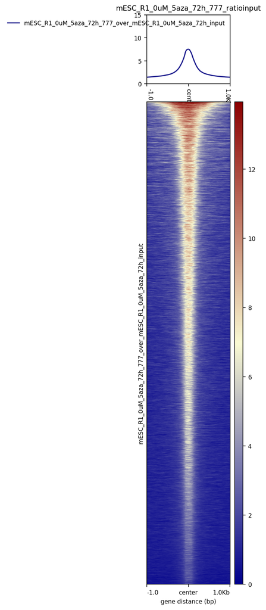

## Tidy Up Your Data and Start Analyzing!